# Machine Learning Project - Spotify Exploration & Analysis

F. Kevin Ryan, Jr.; Kevin Buchanan; Lauren Sapone

11/24/2020

# Load Packages

```r
library(readr)
library(dplyr)
library(tidyverse)
library(ggplot2)
library(ggdark)
library(ggrepel)
library(ggthemes)
library(DT)
library(broom)
library(splitstackshape)
library(randomForest)
library(caret)
library(xgboost)
library(OptimalCutpoints)
library(Metrics)
library(ggforce)
```

# Read in the Dataset

```r
spotify <- read_csv("spotify.csv")
```

# Pre-Processing

### Base Exploration

```r
str(spotify)
```

```
## tibble [169,909 x 19] (S3: spec_tbl_df/tbl_df/tbl/data.frame)
##  $ acousticness    : num [1:169909] 0.995 0.994 0.604 0.995 0.99 0.995 0.956 0.988 0.995 0.846 ...
##  $ artists         : chr [1:169909] "['Carl Woitschach']" "['Robert Schumann', 'Vladimir Horowitz']" "['Seweryn Goszczynski']" "['Francisco Canaro']" ...
##  $ danceability    : num [1:169909] 0.708 0.379 0.749 0.781 0.21 0.424 0.444 0.555 0.683 0.674 ...
##  $ duration_ms     : num [1:169909] 158648 282133 104300 180760 687733 ...
##  $ energy          : num [1:169909] 0.195 0.0135 0.22 0.13 0.204 0.12 0.197 0.421 0.207 0.205 ...
##  $ explicit        : num [1:169909] 0 0 0 0 0 0 0 0 0 0 ...
##  $ id              : chr [1:169909] "6KbQ3uYMLKb5jDxLF7wYDD" "6KuQTIu1KoTTkLXKrwlLPV" "6L63VW0PibdM1HDSBoqnoM" "6M94FkXd15sOAOQYRnWPN8" ...
##  $ instrumentalness: num [1:169909] 0.563 0.901 0 0.887 0.908 0.911 0.435 0.836 0.206 0 ...
##  $ key             : num [1:169909] 10 8 5 1 11 6 11 1 9 9 ...
##  $ liveness        : num [1:169909] 0.151 0.0763 0.119 0.111 0.098 0.0915 0.0744 0.105 0.337 0.17 ...
##  $ loudness        : num [1:169909] -12.4 -28.5 -19.9 -14.7 -16.8 ...
##  $ mode            : num [1:169909] 1 1 0 0 1 0 1 1 0 1 ...
##  $ name            : chr [1:169909] "Singende Bataillone 1. Teil" "Fantasiestücke, Op. 111: Più tosto lento" "Chapter 1.18 - Zamek kaniowski" "Bebamos Juntos - Instrumental (Remasterizado)" ...
##  $ popularity      : num [1:169909] 0 0 0 0 1 0 0 0 0 0 ...
##  $ release_date    : chr [1:169909] "1928" "1928" "1928" "1928-09-25" ...
##  $ speechiness     : num [1:169909] 0.0506 0.0462 0.929 0.0926 0.0424 0.0593 0.04 0.0474 0.127 0.954 ...
##  $ tempo           : num [1:169909] 118.5 84 107.2 108 62.1 ...
##  $ valence         : num [1:169909] 0.779 0.0767 0.88 0.72 0.0693 0.266 0.305 0.857 0.493 0.759 ...
##  $ year            : num [1:169909] 1928 1928 1928 1928 1928 ...
##  - attr(*, "spec")=
##   .. cols(
##   ..   acousticness = col_double(),
##   ..   artists = col_character(),
##   ..   danceability = col_double(),
##   ..   duration_ms = col_double(),
##   ..   energy = col_double(),
##   ..   explicit = col_double(),
##   ..   id = col_character(),
##   ..   instrumentalness = col_double(),
##   ..   key = col_double(),
##   ..   liveness = col_double(),
##   ..   loudness = col_double(),
##   ..   mode = col_double(),
##   ..   name = col_character(),
##   ..   popularity = col_double(),
##   ..   release_date = col_character(),
##   ..   speechiness = col_double(),
##   ..   tempo = col_double(),
##   ..   valence = col_double(),
##   ..   year = col_double()
##   .. )
```

```r
summary(spotify)
```

```
##   acousticness      artists           danceability     duration_ms
##  Min.   :0.0000   Length:169909      Min.   :0.0000   Min.   :   5108
##  1st Qu.:0.0945   Class :character   1st Qu.:0.4170   1st Qu.: 171040
##  Median :0.4920   Mode  :character   Median :0.5480   Median : 208600
##  Mean   :0.4932                      Mean   :0.5381   Mean   : 231406
##  3rd Qu.:0.8880                      3rd Qu.:0.6670   3rd Qu.: 262960
##  Max.   :0.9960                      Max.   :0.9880   Max.   :5403500
##      energy          explicit            id            instrumentalness
##  Min.   :0.0000   Min.   :0.00000   Length:169909      Min.   :0.000000
##  1st Qu.:0.2630   1st Qu.:0.00000   Class :character   1st Qu.:0.000000
##  Median :0.4810   Median :0.00000   Mode  :character   Median :0.000204
##  Mean   :0.4886   Mean   :0.08486                      Mean   :0.161937
##  3rd Qu.:0.7100   3rd Qu.:0.00000                      3rd Qu.:0.086800
##  Max.   :1.0000   Max.   :1.00000                      Max.   :1.000000
##       key            liveness         loudness            mode
##  Min.   : 0.000   Min.   :0.0000   Min.   :-60.000   Min.   :0.0000
##  1st Qu.: 2.000   1st Qu.:0.0984   1st Qu.:-14.470   1st Qu.:0.0000
##  Median : 5.000   Median :0.1350   Median :-10.474   Median :1.0000
##  Mean   : 5.201   Mean   :0.2067   Mean   :-11.370   Mean   :0.7086
##  3rd Qu.: 8.000   3rd Qu.:0.2630   3rd Qu.: -7.118   3rd Qu.:1.0000
##  Max.   :11.000   Max.   :1.0000   Max.   :  3.855   Max.   :1.0000
##      name             popularity     release_date        speechiness
##  Length:169909      Min.   :  0.00   Length:169909      Min.   :0.00000
##  Class :character   1st Qu.: 12.00   Class :character   1st Qu.:0.03490
##  Mode  :character   Median : 33.00   Mode  :character   Median :0.04500
##                     Mean   : 31.56                      Mean   :0.09406
##                     3rd Qu.: 48.00                      3rd Qu.:0.07540
##                     Max.   :100.00                      Max.   :0.96900
##      tempo           valence            year
##  Min.   :  0.00   Min.   :0.0000   Min.   :1921
##  1st Qu.: 93.52   1st Qu.:0.3220   1st Qu.:1957
##  Median :114.78   Median :0.5440   Median :1978
##  Mean   :116.95   Mean   :0.5321   Mean   :1977
##  3rd Qu.:135.71   3rd Qu.:0.7490   3rd Qu.:1999
##  Max.   :244.09   Max.   :1.0000   Max.   :2020
```

```r
head(spotify)
```

```
## # A tibble: 6 x 19
##   acousticness artists danceability duration_ms energy explicit id
##          <dbl> <chr>          <dbl>       <dbl>  <dbl>    <dbl> <chr>
## 1        0.995 ['Carl~        0.708      158648 0.195         0 6KbQ~
## 2        0.994 ['Robe~        0.379      282133 0.0135        0 6KuQ~
## 3        0.604 ['Sewe~        0.749      104300 0.22          0 6L63~
## 4        0.995 ['Fran~        0.781      180760 0.13          0 6M94~
## 5        0.99  ['Fréd~        0.21       687733 0.204         0 6N6t~
## 6        0.995 ['Feli~        0.424      352600 0.12          0 6NxA~
## # ... with 12 more variables: instrumentalness <dbl>, key <dbl>,
## #   liveness <dbl>, loudness <dbl>, mode <dbl>, name <chr>, popularity <dbl>,
## #   release_date <chr>, speechiness <dbl>, tempo <dbl>, valence <dbl>,
## #   year <dbl>
```

```r
tail(spotify)
```

```
## # A tibble: 6 x 19
##   acousticness artists danceability duration_ms energy explicit id
##          <dbl> <chr>          <dbl>       <dbl>  <dbl>    <dbl> <chr>
## 1       0.21   ['LEGA~        0.795      218501  0.585        0 52Cp~
## 2       0.173  ['Drip~        0.875      163800  0.443        1 4Kpp~
## 3       0.0167 ['Leon~        0.719      167468  0.385        0 1ehh~
## 4       0.538  ['Kygo~        0.514      180700  0.539        0 52ey~
## 5       0.0714 ['Cash~        0.646      167308  0.761        0 3wYO~
## 6       0.109  ['Ingr~        0.512      214787  0.428        0 60RF~
## # ... with 12 more variables: instrumentalness <dbl>, key <dbl>,
## #   liveness <dbl>, loudness <dbl>, mode <dbl>, name <chr>, popularity <dbl>,
## #   release_date <chr>, speechiness <dbl>, tempo <dbl>, valence <dbl>,
## #   year <dbl>
```

```r
dim(spotify)
```

```
## [1] 169909     19
```

Seems like our data needs some cleanup before we can visualize and analyze further.

### Remove Unncessary Columns

First, The “id” and “release_date” columns seem to be unnecessary columns and overall just noise in the dataset. The “id” variable is a random jumble of letters and numbers that Spotify assigns to songs, therefore adding no value to our analysis. The “release_date” is a more exact date of release for the song, but they range from the year of the song to the actual day, month, and year, making it very skewed/uneven. Furthermore, we also have the release year in the dataset as the “year” variable, which we believe to be more than enough in terms of timing. Therefore, both variables can be dropped from the dataset.

```r
spotify <- subset(spotify, select = -c(id, release_date))
```

### Reorder Columns

Next, we quickly want to reorder our remaining variables to be more readable to us, putting our key variables to the left (title and artist, followed by our explanatory variables, and our response variable last (popularity)).

```r
spotify <- spotify[, c(12, 2, 17, 1, 3, 4, 5, 6, 7, 8, 9, 10, 11, 14, 15, 16, 13)]
```

### NA’s in the Dataset?

Upon initial exploration, there appears to be no NA’s in the dataset, but just in case we missed anything, we counted the number of NA’s through sum(is.na()).

```r
sum(is.na(spotify))
```

```
## [1] 0
```

The return gave us an answer of 0, signifying that there are no NA values in our dataset.

### Remove Duplicates (if any)

Each observation was unique with the original 19 variables, but after dropping two of the variables, we would like to see if there were any duplicates in the revised dataset. Our thinking is that some songs may have been released twice or more. This would happen in instances where songs are released as a single and then again as a part of an album release, for example.

```r
spotify <- spotify %>%
  distinct()
```

After running the above, above ~600 observations dropped, meaning there were a small number of duplicates in the dataset relative to the total number of songs that we started with.

However, there appear to be some remaining duplicates with the same explanatory variables but different popularity/response variables. So we want to see how many there are and and remove.

```r
dups <- duplicated(spotify[,1:16]) # Checks for remaining duplicates
spotify <- spotify[!dups,]         # Removes those duplicates from the dataset
```

This removed an additional ~2000 observations from our dataset, a good amount dropped but still a small amount relative to the total amount of our original dataset.

### Convert Variables to Appropriate Data Type

Now, we want to convert some variables to the appropriate data types. Currently, all our explanatory variables are numbers, but some need to be factored, specifically the “explicit”, “mode”, “key” variables.

```r
summary(as.factor(spotify$explicit))
```

```
##      0      1
## 153216  14153
```

```r
spotify$explicit <- factor(spotify$explicit, levels=c(0,1), labels=c("No", "Yes")) # Converts 0's to "No" and 1's to "Yes"

summary(as.factor(spotify$mode))
```

```
##      0      1
##  48709 118660
```

```r
spotify$mode <- factor(spotify$mode, levels=c(0,1), labels=c("No", "Yes"))         # Converts 0's to "No" and 1's to "Yes"


summary(as.factor(spotify$key))
```

```
##     0     1     2     3     4     5     6     7     8     9    10    11
## 21199 12615 18530  7075 12719 16139  8437 20478 10558 17335 11869 10415
```

```r
spotify$key <- factor(spotify$key,
                      levels=c(0,1, 2, 3, 4, 5, 6, 7, 8, 9, 10, 11),
                      labels=c("C", "C#", "D", "D#", "E", "F", "F#", "G", "G#", "A", "A#", "B"))
# Converts 0-11 range to appropriate letter on the note scale
str(spotify)
```

```
## tibble [167,369 x 17] (S3: tbl_df/tbl/data.frame)
##  $ name            : chr [1:167369] "Singende Bataillone 1. Teil" "Fantasiestücke, Op. 111: Più tosto lento" "Chapter 1.18 - Zamek kaniowski" "Bebamos Juntos - Instrumental (Remasterizado)" ...
##  $ artists         : chr [1:167369] "['Carl Woitschach']" "['Robert Schumann', 'Vladimir Horowitz']" "['Seweryn Goszczynski']" "['Francisco Canaro']" ...
##  $ year            : num [1:167369] 1928 1928 1928 1928 1928 ...
##  $ acousticness    : num [1:167369] 0.995 0.994 0.604 0.995 0.99 0.995 0.956 0.988 0.995 0.846 ...
##  $ danceability    : num [1:167369] 0.708 0.379 0.749 0.781 0.21 0.424 0.444 0.555 0.683 0.674 ...
##  $ duration_ms     : num [1:167369] 158648 282133 104300 180760 687733 ...
##  $ energy          : num [1:167369] 0.195 0.0135 0.22 0.13 0.204 0.12 0.197 0.421 0.207 0.205 ...
##  $ explicit        : Factor w/ 2 levels "No","Yes": 1 1 1 1 1 1 1 1 1 1 ...
##  $ instrumentalness: num [1:167369] 0.563 0.901 0 0.887 0.908 0.911 0.435 0.836 0.206 0 ...
##  $ key             : Factor w/ 12 levels "C","C#","D","D#",..: 11 9 6 2 12 7 12 2 10 10 ...
##  $ liveness        : num [1:167369] 0.151 0.0763 0.119 0.111 0.098 0.0915 0.0744 0.105 0.337 0.17 ...
##  $ loudness        : num [1:167369] -12.4 -28.5 -19.9 -14.7 -16.8 ...
##  $ mode            : Factor w/ 2 levels "No","Yes": 2 2 1 1 2 1 2 2 1 2 ...
##  $ speechiness     : num [1:167369] 0.0506 0.0462 0.929 0.0926 0.0424 0.0593 0.04 0.0474 0.127 0.954 ...
##  $ tempo           : num [1:167369] 118.5 84 107.2 108 62.1 ...
##  $ valence         : num [1:167369] 0.779 0.0767 0.88 0.72 0.0693 0.266 0.305 0.857 0.493 0.759 ...
##  $ popularity      : num [1:167369] 0 0 0 0 1 0 0 0 0 0 ...
```

### Revised Data Exploraton

After all the revisions to the dataset, let us now see what it looks like.

```r
str(spotify)
```

```
## tibble [167,369 x 17] (S3: tbl_df/tbl/data.frame)
##  $ name            : chr [1:167369] "Singende Bataillone 1. Teil" "Fantasiestücke, Op. 111: Più tosto lento" "Chapter 1.18 - Zamek kaniowski" "Bebamos Juntos - Instrumental (Remasterizado)" ...
##  $ artists         : chr [1:167369] "['Carl Woitschach']" "['Robert Schumann', 'Vladimir Horowitz']" "['Seweryn Goszczynski']" "['Francisco Canaro']" ...
##  $ year            : num [1:167369] 1928 1928 1928 1928 1928 ...
##  $ acousticness    : num [1:167369] 0.995 0.994 0.604 0.995 0.99 0.995 0.956 0.988 0.995 0.846 ...
##  $ danceability    : num [1:167369] 0.708 0.379 0.749 0.781 0.21 0.424 0.444 0.555 0.683 0.674 ...
##  $ duration_ms     : num [1:167369] 158648 282133 104300 180760 687733 ...
##  $ energy          : num [1:167369] 0.195 0.0135 0.22 0.13 0.204 0.12 0.197 0.421 0.207 0.205 ...
##  $ explicit        : Factor w/ 2 levels "No","Yes": 1 1 1 1 1 1 1 1 1 1 ...
##  $ instrumentalness: num [1:167369] 0.563 0.901 0 0.887 0.908 0.911 0.435 0.836 0.206 0 ...
##  $ key             : Factor w/ 12 levels "C","C#","D","D#",..: 11 9 6 2 12 7 12 2 10 10 ...
##  $ liveness        : num [1:167369] 0.151 0.0763 0.119 0.111 0.098 0.0915 0.0744 0.105 0.337 0.17 ...
##  $ loudness        : num [1:167369] -12.4 -28.5 -19.9 -14.7 -16.8 ...
##  $ mode            : Factor w/ 2 levels "No","Yes": 2 2 1 1 2 1 2 2 1 2 ...
##  $ speechiness     : num [1:167369] 0.0506 0.0462 0.929 0.0926 0.0424 0.0593 0.04 0.0474 0.127 0.954 ...
##  $ tempo           : num [1:167369] 118.5 84 107.2 108 62.1 ...
##  $ valence         : num [1:167369] 0.779 0.0767 0.88 0.72 0.0693 0.266 0.305 0.857 0.493 0.759 ...
##  $ popularity      : num [1:167369] 0 0 0 0 1 0 0 0 0 0 ...
```

```r
summary(spotify)
```

```
##      name             artists               year       acousticness
##  Length:167369      Length:167369      Min.   :1921   Min.   :0.0000
##  Class :character   Class :character   1st Qu.:1957   1st Qu.:0.0956
##  Mode  :character   Mode  :character   Median :1978   Median :0.4940
##                                        Mean   :1977   Mean   :0.4937
##                                        3rd Qu.:1999   3rd Qu.:0.8870
##                                        Max.   :2020   Max.   :0.9960
##
##   danceability     duration_ms          energy       explicit
##  Min.   :0.0000   Min.   :   5108   Min.   :0.0000   No :153216
##  1st Qu.:0.4180   1st Qu.: 171027   1st Qu.:0.2630   Yes: 14153
##  Median :0.5490   Median : 208373   Median :0.4800
##  Mean   :0.5388   Mean   : 231276   Mean   :0.4882
##  3rd Qu.:0.6680   3rd Qu.: 262720   3rd Qu.:0.7080
##  Max.   :0.9880   Max.   :5403500   Max.   :1.0000
##
##  instrumentalness        key           liveness         loudness
##  Min.   :0.000000   C      :21199   Min.   :0.0000   Min.   :-60.000
##  1st Qu.:0.000000   G      :20478   1st Qu.:0.0984   1st Qu.:-14.460
##  Median :0.000197   D      :18530   Median :0.1350   Median :-10.486
##  Mean   :0.160895   A      :17335   Mean   :0.2069   Mean   :-11.369
##  3rd Qu.:0.084200   F      :16139   3rd Qu.:0.2630   3rd Qu.: -7.138
##  Max.   :1.000000   E      :12719   Max.   :1.0000   Max.   :  3.855
##                     (Other):60969
##   mode         speechiness          tempo           valence
##  No : 48709   Min.   :0.00000   Min.   :  0.00   Min.   :0.0000
##  Yes:118660   1st Qu.:0.03490   1st Qu.: 93.53   1st Qu.:0.3240
##               Median :0.04510   Median :114.78   Median :0.5460
##               Mean   :0.09439   Mean   :116.95   Mean   :0.5333
##               3rd Qu.:0.07550   3rd Qu.:135.70   3rd Qu.:0.7510
##               Max.   :0.96900   Max.   :244.09   Max.   :1.0000
##
##    popularity
##  Min.   :  0.00
##  1st Qu.: 12.00
##  Median : 33.00
##  Mean   : 31.55
##  3rd Qu.: 48.00
##  Max.   :100.00
##
```

```r
head(spotify)
```

```
## # A tibble: 6 x 17
##   name  artists  year acousticness danceability duration_ms energy explicit
##   <chr> <chr>   <dbl>        <dbl>        <dbl>       <dbl>  <dbl> <fct>
## 1 Sing~ ['Carl~  1928        0.995        0.708      158648 0.195  No
## 2 Fant~ ['Robe~  1928        0.994        0.379      282133 0.0135 No
## 3 Chap~ ['Sewe~  1928        0.604        0.749      104300 0.22   No
## 4 Beba~ ['Fran~  1928        0.995        0.781      180760 0.13   No
## 5 Polo~ ['Fréd~  1928        0.99         0.21       687733 0.204  No
## 6 Sche~ ['Feli~  1928        0.995        0.424      352600 0.12   No
## # ... with 9 more variables: instrumentalness <dbl>, key <fct>, liveness <dbl>,
## #   loudness <dbl>, mode <fct>, speechiness <dbl>, tempo <dbl>, valence <dbl>,
## #   popularity <dbl>
```

```r
tail(spotify)
```

```
## # A tibble: 6 x 17
##   name  artists  year acousticness danceability duration_ms energy explicit
##   <chr> <chr>   <dbl>        <dbl>        <dbl>       <dbl>  <dbl> <fct>
## 1 Ojos~ ['LEGA~  2020       0.21          0.795      218501  0.585 No
## 2 Skec~ ['Drip~  2020       0.173         0.875      163800  0.443 Yes
## 3 Swee~ ['Leon~  2020       0.0167        0.719      167468  0.385 No
## 4 How ~ ['Kygo~  2020       0.538         0.514      180700  0.539 No
## 5 I Fo~ ['Cash~  2020       0.0714        0.646      167308  0.761 No
## 6 More~ ['Ingr~  2020       0.109         0.512      214787  0.428 No
## # ... with 9 more variables: instrumentalness <dbl>, key <fct>, liveness <dbl>,
## #   loudness <dbl>, mode <fct>, speechiness <dbl>, tempo <dbl>, valence <dbl>,
## #   popularity <dbl>
```

```r
dim(spotify)
```

```
## [1] 167369     17
```

# Base Exploration

### Explore the Distribution of Variables

Before diving deep into the data from a visual perspective, let us look at distribution of the numeric response variables with histograms just to get a sense of where these variables lie.

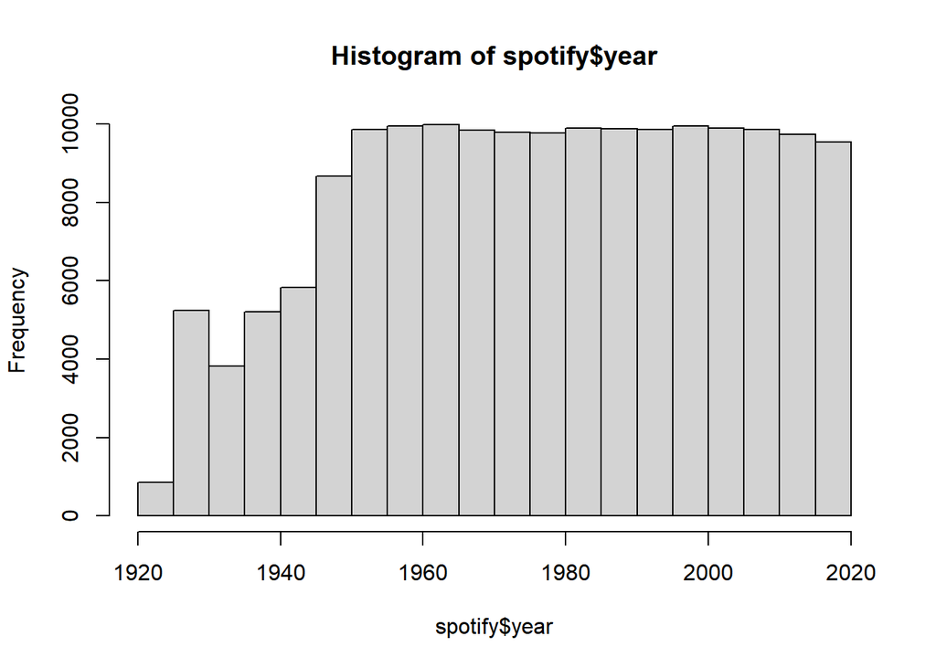

```r
hist(spotify$year)
```

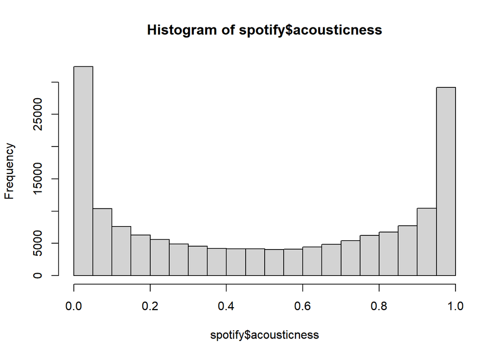

```r
hist(spotify$acousticness)
```

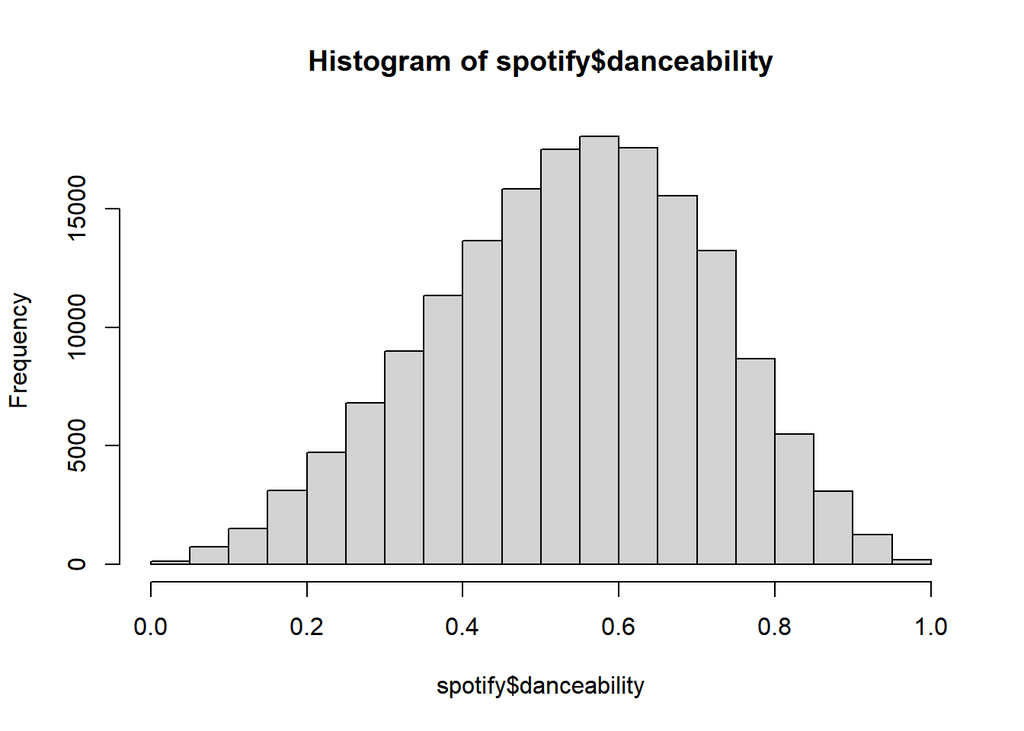

```r
hist(spotify$danceability)
```

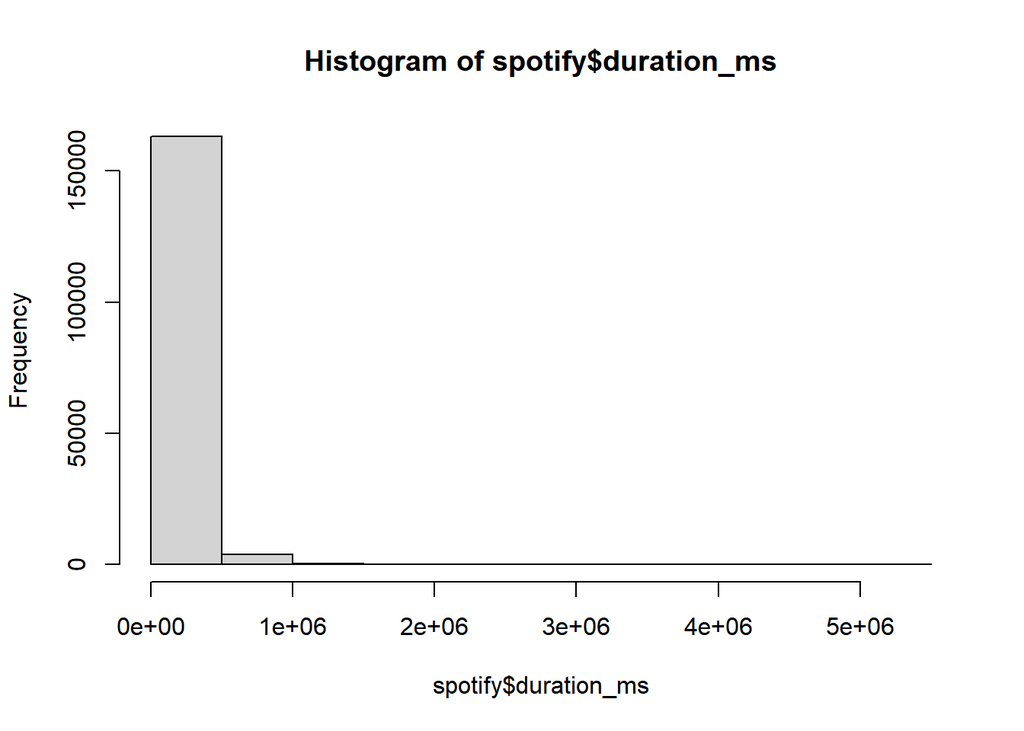

```r
hist(spotify$duration_ms)
```

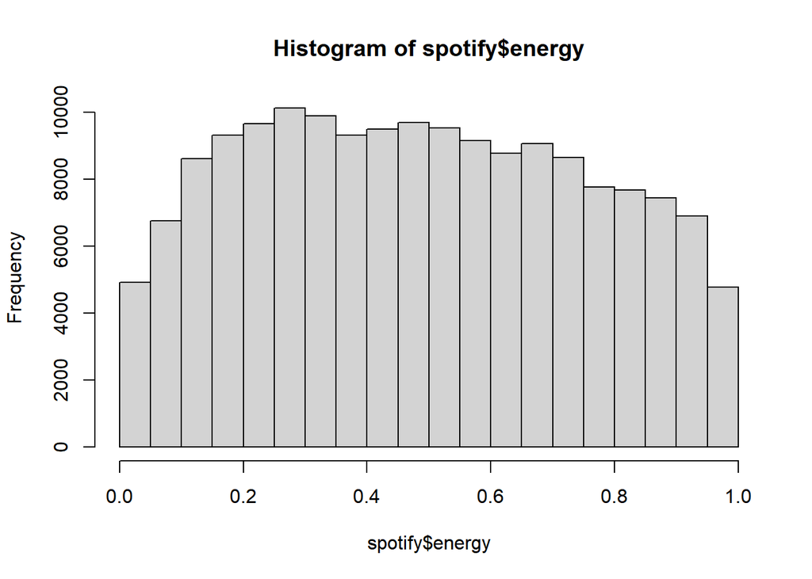

```r
hist(spotify$energy)
```

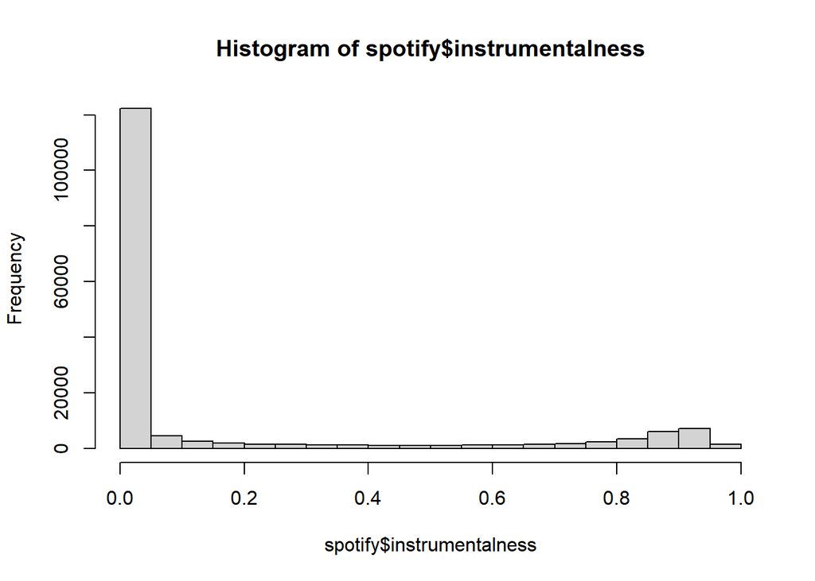

```r
hist(spotify$instrumentalness)
```

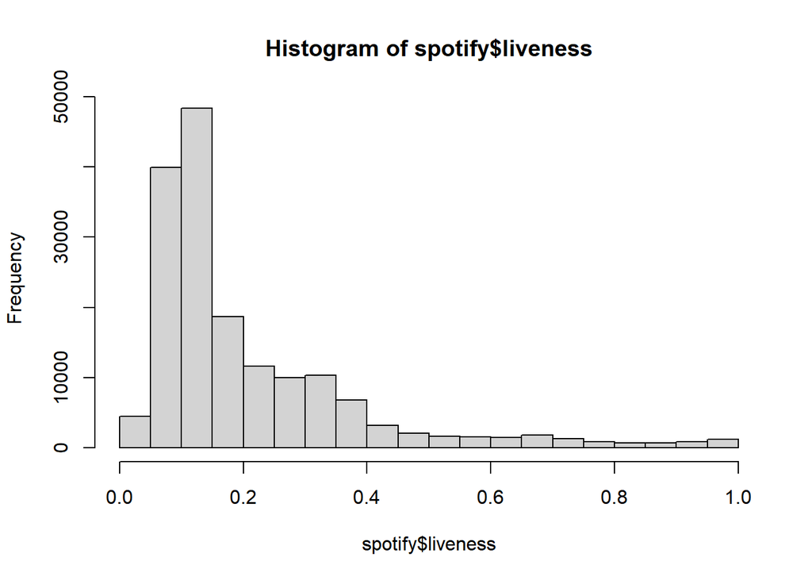

```r
hist(spotify$liveness)
```

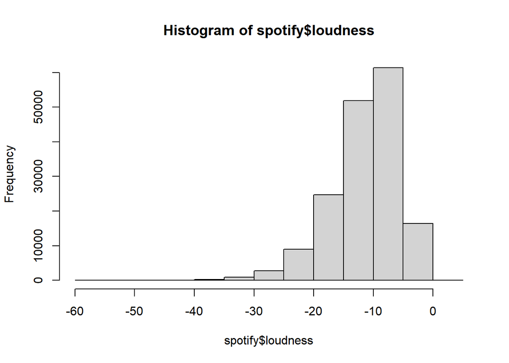

```r
hist(spotify$loudness)
```

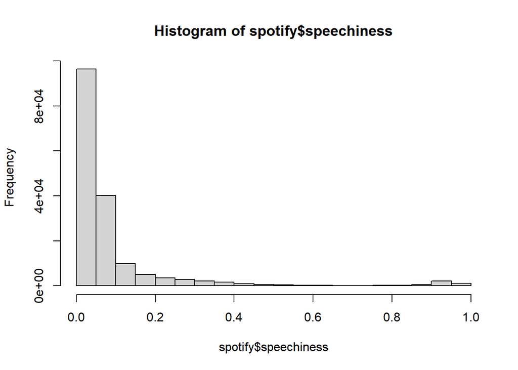

```r
hist(spotify$speechiness)
```

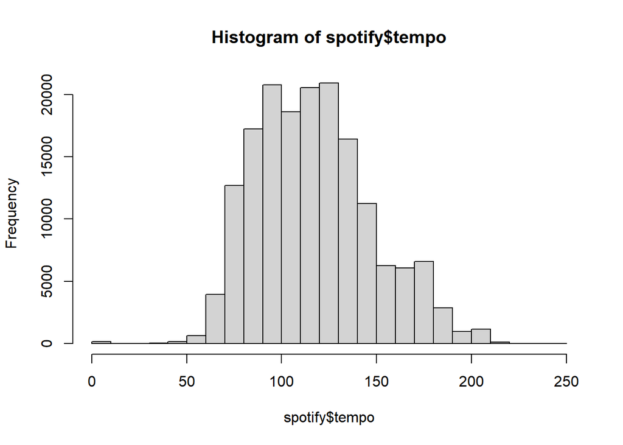

```r
hist(spotify$tempo)
```

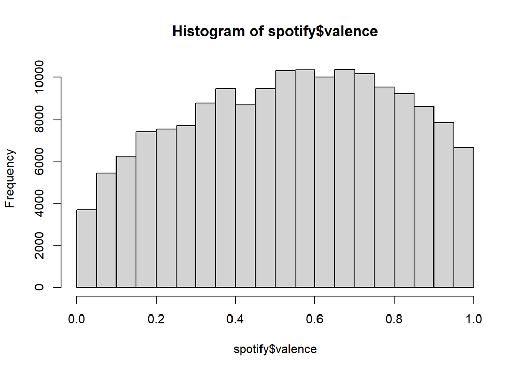

```r
hist(spotify$valence)
```

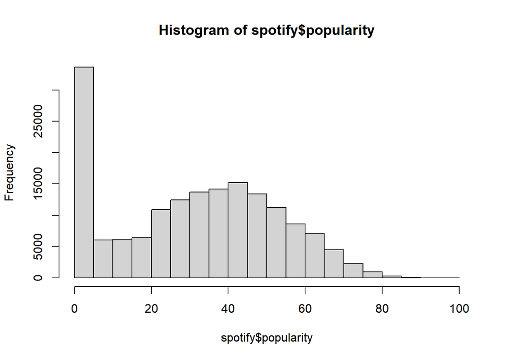

```r
hist(spotify$popularity)
```

### Visualizations

Since our response variable is going to be popularity, we thought it best to explore some of the data in relation to a song’s popularity.

We will be using scatter plots with regression lines to explore our data so we want to included two lines: one smoothed and one linear.

```r
formula1 = y ~ x # formula for the linear regression
formula2 <- y ~ splines::bs(x, 4) # formula for the smoothed line
```

**Popularity Ratings over the Years**

From initial observations, it seemed that the year a song was released had a positive relationship on the song’s popularity. In other words, it seemed that the more recent a song was released, the higher its popularity is. Thus, we decided to visualize on a scatter plot with regression lines.

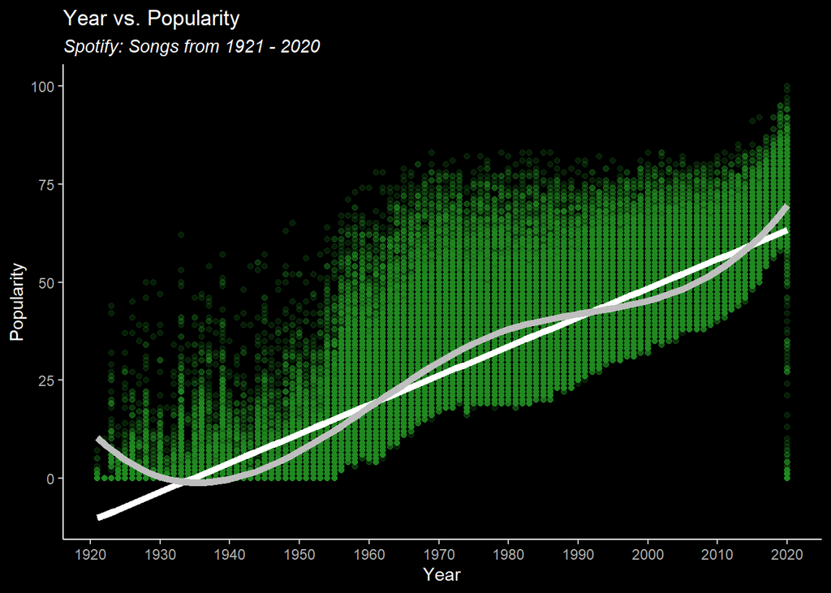

```r
x_1 <- ggplot(spotify, aes(x=year, y=popularity)) +
  dark_theme_bw() +
  geom_point(color = "forestgreen", alpha = 0.2) +
  geom_smooth(method = "lm",
              formula = formula1,
              color = "white",
              size = 2,
              se = FALSE) +
  geom_smooth(method = "gam",
              formula = formula2,
              color = "grey75",
              size = 2,
              se = FALSE) +
  labs(x = "Year",
       y = "Popularity",
       title = "Year vs. Popularity",
       subtitle = "Spotify: Songs from 1921 - 2020") +
  theme(axis.line = element_line(colour = "white"),
        panel.grid.major = element_blank(),
        panel.grid.minor = element_blank(),
        panel.border = element_blank(),
        panel.background = element_blank(),
        plot.subtitle = element_text(face = "italic")) +
  scale_x_continuous(breaks=seq(from = 1920, to = 2020, by = 10))
x_1
```

As seen above, there is a positive relationship between popularity and the year of a song’s release, even though the fitted line has a bit more fluctuation over time. Nevertheless, both lines show positive relationships.

**Popularity vs. Energy**

Another relationship we wanted to explore was the relationship between popularity and the energy of a song. Intuition is telling us that the more energy a song has, the more popular it will be. This is because popularity ratings are based off the modern day popularity ratings in the United States and a lot of modern day music that is popular in the United States gives off more energy.

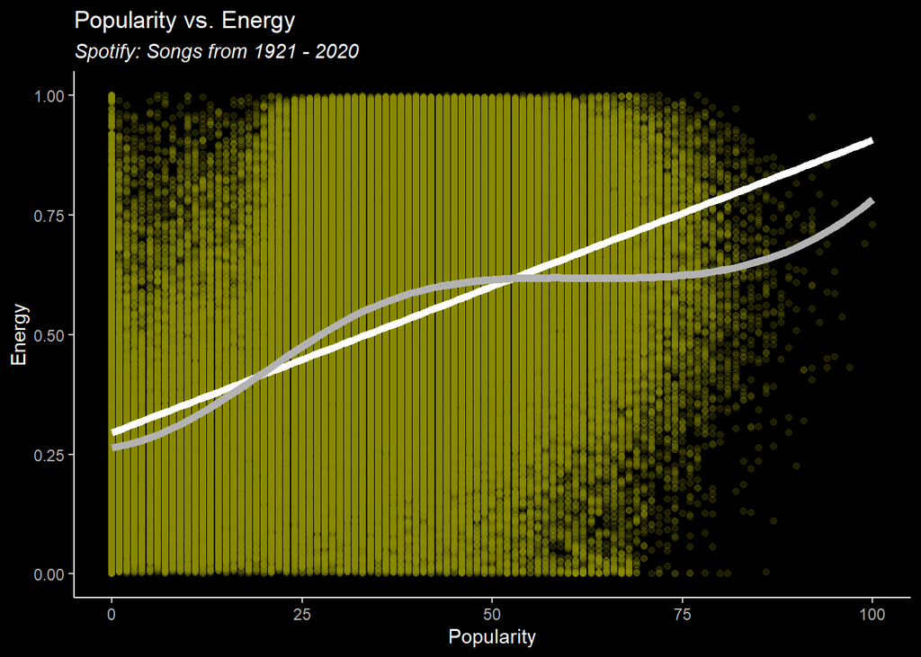

```r
x_2 <- ggplot(spotify, aes(x=popularity, y=energy)) +
  dark_theme_bw() +
  geom_point(color = "yellow4", alpha = 0.2) +
  geom_smooth(method = "lm",
              formula = formula1,
              color = "white",
              size = 2,
              se = FALSE) +
  geom_smooth(method = "gam",
              formula = formula2,
              color = "grey70",
              size = 2,
              se = FALSE) +
  labs(x = "Popularity",
       y = "Energy",
       title = "Popularity vs. Energy",
       subtitle = "Spotify: Songs from 1921 - 2020") +
  theme(axis.line = element_line(colour = "white"),
        panel.grid.major = element_blank(),
        panel.grid.minor = element_blank(),
        panel.border = element_blank(),
        panel.background = element_blank(),
        plot.subtitle = element_text(face = "italic"))
x_2
```

As seen above, there is a positive relationship between popularity and the energy a song gives off. Again, like the previous graph, the fitted line has a bit more fluctuation over the popularity scale. Nevertheless, both lines show positive relationships.

**Popularity Distribution among Explicit and Not Explicit**

We also wanted to look at popularity by itself and break it down by an explanatory variable. One variable that we find interesting is the explicit variable and how it distributed throughout the popularity variable. Thus, we decided to use a density plot to see that distribution.

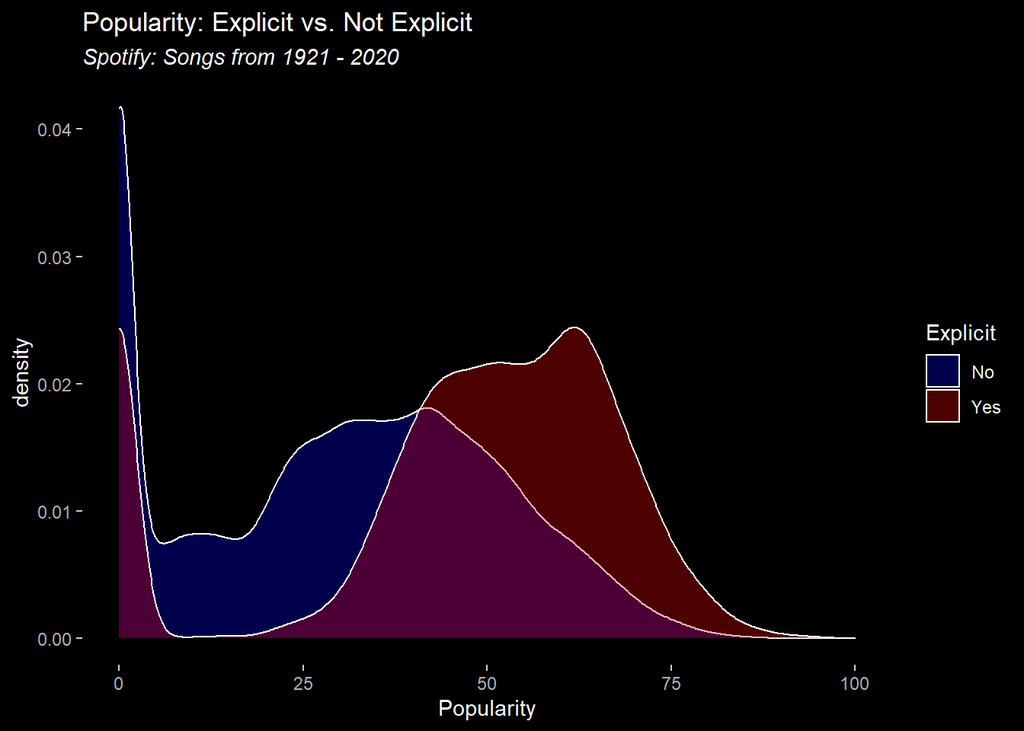

```r
x_3 <- ggplot(spotify, aes(x = popularity, fill = explicit)) +
  geom_density(alpha = 0.3) +
  dark_theme_bw() +
  labs(x = "Popularity",
       title = "Popularity: Explicit vs. Not Explicit",
       subtitle = "Spotify: Songs from 1921 - 2020",
       fill = "Explicit") +
    theme(panel.grid.major = element_blank(),
        panel.grid.minor = element_blank(),
        panel.border = element_blank(),
        panel.background = element_blank(),
        plot.subtitle = element_text(face = "italic")) +
  scale_fill_manual(values = c("Yes" = "red", "No" = "blue"))
x_3
```

As seen above, explicit songs belong in a higher distribution/range of popularity than none explicit songs. However, both explicit and none explicit songs have a good amount of songs that are low in popularity.

### Linear Regression

Now, let’s see how a linear regression runs, using popularity as the response variable and including all the explanatory variables in the model.

```r
spotify_fit1 <- lm(popularity ~
                     year +
                     acousticness +
                     danceability +
                     duration_ms +
                     energy +
                     explicit +
                     instrumentalness +
                     liveness +
                     key +
                     loudness +
                     mode +
                     speechiness +
                     tempo +
                     valence,
                 data = spotify)

summary(spotify_fit1)
```

```
##
## Call:
## lm(formula = popularity ~ year + acousticness + danceability +
##     duration_ms + energy + explicit + instrumentalness + liveness +
##     key + loudness + mode + speechiness + tempo + valence, data = spotify)
##
## Residuals:
##     Min      1Q  Median      3Q     Max
## -64.657  -7.186  -1.601   5.270  61.441
##
## Coefficients:
##                    Estimate Std. Error  t value Pr(>|t|)
## (Intercept)      -1.322e+03  2.745e+00 -481.594  < 2e-16 ***
## year              6.854e-01  1.376e-03  498.195  < 2e-16 ***
## acousticness     -4.001e+00  1.135e-01  -35.236  < 2e-16 ***
## danceability      4.746e+00  1.961e-01   24.200  < 2e-16 ***
## duration_ms       1.864e-07  2.091e-07    0.891  0.37276
## energy           -1.178e+00  2.033e-01   -5.794 6.87e-09 ***
## explicitYes       5.195e-01  1.046e-01    4.965 6.89e-07 ***
## instrumentalness -2.523e+00  9.226e-02  -27.344  < 2e-16 ***
## liveness         -2.459e+00  1.452e-01  -16.932  < 2e-16 ***
## keyC#            -1.173e-01  1.131e-01   -1.038  0.29946
## keyD             -7.582e-02  1.006e-01   -0.754  0.45096
## keyD#            -2.979e-01  1.377e-01   -2.163  0.03053 *
## keyE              2.020e-01  1.130e-01    1.788  0.07373 .
## keyF              1.786e-02  1.048e-01    0.170  0.86468
## keyF#             6.791e-03  1.295e-01    0.052  0.95818
## keyG             -9.864e-02  9.792e-02   -1.007  0.31377
## keyG#            -1.809e-01  1.191e-01   -1.518  0.12892
## keyA              1.147e-01  1.028e-01    1.116  0.26446
## keyA#            -1.680e-01  1.150e-01   -1.461  0.14394
## keyB             -3.451e-01  1.215e-01   -2.841  0.00450 **
## loudness          2.262e-02  7.719e-03    2.931  0.00338 **
## modeYes          -2.506e-01  5.561e-02   -4.506 6.61e-06 ***
## speechiness      -7.694e+00  1.970e-01  -39.057  < 2e-16 ***
## tempo             5.080e-03  8.382e-04    6.060 1.37e-09 ***
## valence          -2.956e-01  1.339e-01   -2.208  0.02724 *
## ---
## Signif. codes:  0 '***' 0.001 '**' 0.01 '*' 0.05 '.' 0.1 ' ' 1
##
## Residual standard error: 9.992 on 167344 degrees of freedom
## Multiple R-squared:  0.7847, Adjusted R-squared:  0.7847
## F-statistic: 2.542e+04 on 24 and 167344 DF,  p-value: < 2.2e-16
```

As seen above, this model is statistically significant, with a p-value essentially at 0. Most of our explanatory variables are statistically significant, although most of the key and the duration_ms variables are well above the 0.05 threshold for significance. Of the variables that are significant, it seems that the year, tempo, and danceability are increasing the popularity of a song the more prevalent they are in a song. In the reverse, speechiness and accousticness are decreasing the popularity of a song the more present they are in a song.

This model has a pretty decent R Squared at 0.7847, meaning that the current model is explaining about 78.5% of the variation in the song’s popularity.

**Introduction of Interaction Term**

From there, we wanted to look at the introduction of an interaction term into the model. In particular, we thought that tempo and danceability might have some type of interaction/relationship between each other. In other words, we would think that the danceability of a song is influenced by that song’s tempo. So, we re-ran the regression model with that interaction included in the model.

[output not shown]

# Analysis

Our ultimate goal in working with this dataset is to learn which variables, and what amounts of those variables, are most important in determining the popularity of a song. In order to best do that, we need to run some models that can predict song popularity, tune them to increase their accuracy, and then extract variable importance from them. So let us dive into that process below.

We plan to split our training and test datasets based off the decade a song is in, so we will need to create that variable and add it to our data. This is only a “temporary” variable in the sense that it will only be created to group/split the variables into the training and test, but will not be included in those datasets when our models and tuning are run.

### Create Decade Variable and Add to Dataset

```r
spotify$decade <- round(spotify$year - 5, digits = -1) # creates the decade variable

str(spotify) # See how it looks in our dataset
```

```
## tibble [167,369 x 18] (S3: tbl_df/tbl/data.frame)
##  $ name            : chr [1:167369] "Singende Bataillone 1. Teil" "Fantasiestücke, Op. 111: Più tosto lento" "Chapter 1.18 - Zamek kaniowski" "Bebamos Juntos - Instrumental (Remasterizado)" ...
##  $ artists         : chr [1:167369] "['Carl Woitschach']" "['Robert Schumann', 'Vladimir Horowitz']" "['Seweryn Goszczynski']" "['Francisco Canaro']" ...
##  $ year            : num [1:167369] 1928 1928 1928 1928 1928 ...
##  $ acousticness    : num [1:167369] 0.995 0.994 0.604 0.995 0.99 0.995 0.956 0.988 0.995 0.846 ...
##  $ danceability    : num [1:167369] 0.708 0.379 0.749 0.781 0.21 0.424 0.444 0.555 0.683 0.674 ...
##  $ duration_ms     : num [1:167369] 158648 282133 104300 180760 687733 ...
##  $ energy          : num [1:167369] 0.195 0.0135 0.22 0.13 0.204 0.12 0.197 0.421 0.207 0.205 ...
##  $ explicit        : Factor w/ 2 levels "No","Yes": 1 1 1 1 1 1 1 1 1 1 ...
##  $ instrumentalness: num [1:167369] 0.563 0.901 0 0.887 0.908 0.911 0.435 0.836 0.206 0 ...
##  $ key             : Factor w/ 12 levels "C","C#","D","D#",..: 11 9 6 2 12 7 12 2 10 10 ...
##  $ liveness        : num [1:167369] 0.151 0.0763 0.119 0.111 0.098 0.0915 0.0744 0.105 0.337 0.17 ...
##  $ loudness        : num [1:167369] -12.4 -28.5 -19.9 -14.7 -16.8 ...
##  $ mode            : Factor w/ 2 levels "No","Yes": 2 2 1 1 2 1 2 2 1 2 ...
##  $ speechiness     : num [1:167369] 0.0506 0.0462 0.929 0.0926 0.0424 0.0593 0.04 0.0474 0.127 0.954 ...
##  $ tempo           : num [1:167369] 118.5 84 107.2 108 62.1 ...
##  $ valence         : num [1:167369] 0.779 0.0767 0.88 0.72 0.0693 0.266 0.305 0.857 0.493 0.759 ...
##  $ popularity      : num [1:167369] 0 0 0 0 1 0 0 0 0 0 ...
##  $ decade          : num [1:167369] 1920 1920 1920 1920 1920 1920 1920 1920 1920 1920 ...
```

### Create Training and Test Datasets for Random Forest Model

```r
set.seed(2374) # Set seed

# Drop song name, artist name, year, and convert to indicators
x_vars <- as.data.frame(model.matrix(popularity~., data = spotify[,4:18]))[,-1]
x_vars$popularity <- spotify$popularity
names(x_vars) <- make.names(names(x_vars))
names(x_vars)
```

```
##  [1] "acousticness"     "danceability"     "duration_ms"      "energy"
##  [5] "explicitYes"      "instrumentalness" "keyC."            "keyD"
##  [9] "keyD."            "keyE"             "keyF"             "keyF."
## [13] "keyG"             "keyG."            "keyA"             "keyA."
## [17] "keyB"             "liveness"         "loudness"         "modeYes"
## [21] "speechiness"      "tempo"            "valence"          "decade"
## [25] "popularity"
```

```r
# Perform stratified sampling
spot_split_dat <- stratified(x_vars, # Set dataset
                         group = "decade", # Set variables to use for stratification
                         size = 0.2,  # Set size of test set
                         bothSets = TRUE ) # Return both training and test sets

 # Extract train data - drop decade
 spot_train_dat <- spot_split_dat[[2]][,c(1:23, 25)]
 # Extract test data
 spot_test_dat <- spot_split_dat[[1]][,c(1:23, 25)]

# Check size
nrow(spot_train_dat)
```

```
## [1] 133896
```

```r
nrow(spot_test_dat)
```

```
## [1] 33473
```

```r
summary(spot_train_dat)
```

```
##   acousticness     danceability     duration_ms          energy
##  Min.   :0.0000   Min.   :0.0000   Min.   :   5108   Min.   :0.0000
##  1st Qu.:0.0950   1st Qu.:0.4190   1st Qu.: 170973   1st Qu.:0.2630
##  Median :0.4930   Median :0.5490   Median : 208493   Median :0.4800
##  Mean   :0.4934   Mean   :0.5391   Mean   : 231517   Mean   :0.4881
##  3rd Qu.:0.8870   3rd Qu.:0.6680   3rd Qu.: 263173   3rd Qu.:0.7080
##  Max.   :0.9960   Max.   :0.9880   Max.   :5403500   Max.   :1.0000
##   explicitYes      instrumentalness       keyC.              keyD
##  Min.   :0.00000   Min.   :0.000000   Min.   :0.00000   Min.   :0.0000
##  1st Qu.:0.00000   1st Qu.:0.000000   1st Qu.:0.00000   1st Qu.:0.0000
##  Median :0.00000   Median :0.000195   Median :0.00000   Median :0.0000
##  Mean   :0.08406   Mean   :0.161198   Mean   :0.07562   Mean   :0.1103
##  3rd Qu.:0.00000   3rd Qu.:0.085300   3rd Qu.:0.00000   3rd Qu.:0.0000
##  Max.   :1.00000   Max.   :1.000000   Max.   :1.00000   Max.   :1.0000
##      keyD.              keyE             keyF             keyF.
##  Min.   :0.00000   Min.   :0.0000   Min.   :0.00000   Min.   :0.00000
##  1st Qu.:0.00000   1st Qu.:0.0000   1st Qu.:0.00000   1st Qu.:0.00000
##  Median :0.00000   Median :0.0000   Median :0.00000   Median :0.00000
##  Mean   :0.04242   Mean   :0.0762   Mean   :0.09692   Mean   :0.05033
##  3rd Qu.:0.00000   3rd Qu.:0.0000   3rd Qu.:0.00000   3rd Qu.:0.00000
##  Max.   :1.00000   Max.   :1.0000   Max.   :1.00000   Max.   :1.00000
##       keyG            keyG.             keyA            keyA.
##  Min.   :0.0000   Min.   :0.0000   Min.   :0.0000   Min.   :0.00000
##  1st Qu.:0.0000   1st Qu.:0.0000   1st Qu.:0.0000   1st Qu.:0.00000
##  Median :0.0000   Median :0.0000   Median :0.0000   Median :0.00000
##  Mean   :0.1228   Mean   :0.0627   Mean   :0.1032   Mean   :0.07094
##  3rd Qu.:0.0000   3rd Qu.:0.0000   3rd Qu.:0.0000   3rd Qu.:0.00000
##  Max.   :1.0000   Max.   :1.0000   Max.   :1.0000   Max.   :1.00000
##       keyB           liveness         loudness          modeYes
##  Min.   :0.0000   Min.   :0.0000   Min.   :-60.000   Min.   :0.0000
##  1st Qu.:0.0000   1st Qu.:0.0984   1st Qu.:-14.444   1st Qu.:0.0000
##  Median :0.0000   Median :0.1350   Median :-10.492   Median :1.0000
##  Mean   :0.0619   Mean   :0.2070   Mean   :-11.365   Mean   :0.7087
##  3rd Qu.:0.0000   3rd Qu.:0.2630   3rd Qu.: -7.143   3rd Qu.:1.0000
##  Max.   :1.0000   Max.   :1.0000   Max.   :  3.855   Max.   :1.0000
##   speechiness          tempo           valence         popularity
##  Min.   :0.00000   Min.   :  0.00   Min.   :0.0000   Min.   :  0.00
##  1st Qu.:0.03490   1st Qu.: 93.61   1st Qu.:0.3240   1st Qu.: 12.00
##  Median :0.04510   Median :114.82   Median :0.5460   Median : 33.00
##  Mean   :0.09442   Mean   :117.01   Mean   :0.5337   Mean   : 31.55
##  3rd Qu.:0.07550   3rd Qu.:135.77   3rd Qu.:0.7510   3rd Qu.: 48.00
##  Max.   :0.96900   Max.   :244.09   Max.   :1.0000   Max.   :100.00
```

```r
summary(spot_test_dat)
```

```
##   acousticness     danceability     duration_ms          energy
##  Min.   :0.0000   Min.   :0.0000   Min.   :   6467   Min.   :0.0000
##  1st Qu.:0.0980   1st Qu.:0.4150   1st Qu.: 171333   1st Qu.:0.2630
##  Median :0.4990   Median :0.5470   Median : 207905   Median :0.4810
##  Mean   :0.4951   Mean   :0.5374   Mean   : 230310   Mean   :0.4885
##  3rd Qu.:0.8890   3rd Qu.:0.6670   3rd Qu.: 260987   3rd Qu.:0.7110
##  Max.   :0.9960   Max.   :0.9850   Max.   :4120258   Max.   :1.0000
##   explicitYes      instrumentalness       keyC.              keyD
##  Min.   :0.00000   Min.   :0.000000   Min.   :0.00000   Min.   :0.0000
##  1st Qu.:0.00000   1st Qu.:0.000000   1st Qu.:0.00000   1st Qu.:0.0000
##  Median :0.00000   Median :0.000205   Median :0.00000   Median :0.0000
##  Mean   :0.08658   Mean   :0.159680   Mean   :0.07439   Mean   :0.1122
##  3rd Qu.:0.00000   3rd Qu.:0.079600   3rd Qu.:0.00000   3rd Qu.:0.0000
##  Max.   :1.00000   Max.   :1.000000   Max.   :1.00000   Max.   :1.0000
##      keyD.              keyE              keyF             keyF.
##  Min.   :0.00000   Min.   :0.00000   Min.   :0.00000   Min.   :0.00000
##  1st Qu.:0.00000   1st Qu.:0.00000   1st Qu.:0.00000   1st Qu.:0.00000
##  Median :0.00000   Median :0.00000   Median :0.00000   Median :0.00000
##  Mean   :0.04168   Mean   :0.07517   Mean   :0.09446   Mean   :0.05073
##  3rd Qu.:0.00000   3rd Qu.:0.00000   3rd Qu.:0.00000   3rd Qu.:0.00000
##  Max.   :1.00000   Max.   :1.00000   Max.   :1.00000   Max.   :1.00000
##       keyG            keyG.              keyA            keyA.
##  Min.   :0.0000   Min.   :0.00000   Min.   :0.0000   Min.   :0.00000
##  1st Qu.:0.0000   1st Qu.:0.00000   1st Qu.:0.0000   1st Qu.:0.00000
##  Median :0.0000   Median :0.00000   Median :0.0000   Median :0.00000
##  Mean   :0.1207   Mean   :0.06462   Mean   :0.1051   Mean   :0.07083
##  3rd Qu.:0.0000   3rd Qu.:0.00000   3rd Qu.:0.0000   3rd Qu.:0.00000
##  Max.   :1.0000   Max.   :1.00000   Max.   :1.0000   Max.   :1.00000
##       keyB            liveness         loudness         modeYes
##  Min.   :0.00000   Min.   :0.0000   Min.   :-60.00   Min.   :0.0000
##  1st Qu.:0.00000   1st Qu.:0.0986   1st Qu.:-14.53   1st Qu.:0.0000
##  Median :0.00000   Median :0.1360   Median :-10.46   Median :1.0000
##  Mean   :0.06354   Mean   :0.2062   Mean   :-11.39   Mean   :0.7101
##  3rd Qu.:0.00000   3rd Qu.:0.2620   3rd Qu.: -7.12   3rd Qu.:1.0000
##  Max.   :1.00000   Max.   :0.9970   Max.   :  1.83   Max.   :1.0000
##   speechiness          tempo           valence         popularity
##  Min.   :0.00000   Min.   :  0.00   Min.   :0.0000   Min.   : 0.00
##  1st Qu.:0.03490   1st Qu.: 93.21   1st Qu.:0.3230   1st Qu.:12.00
##  Median :0.04500   Median :114.62   Median :0.5440   Median :33.00
##  Mean   :0.09427   Mean   :116.70   Mean   :0.5317   Mean   :31.55
##  3rd Qu.:0.07560   3rd Qu.:135.43   3rd Qu.:0.7500   3rd Qu.:48.00
##  Max.   :0.96800   Max.   :243.51   Max.   :0.9930   Max.   :92.00
```

### Run Random Forest Model

```r
spot_bag <- randomForest(popularity ~.,# Set tree formula
                data = spot_train_dat, # Set dataset
                ntree = 200, # Set number of trees to use
                do.trace = TRUE)
```

```
##      |      Out-of-bag   |
## Tree |      MSE  %Var(y) |
##    1 |    358.3    77.24 |
##    2 |    341.6    73.63 |
##    3 |    320.7    69.14 |
##    4 |    303.3    65.38 |
##    5 |    287.6    62.00 |
##    6 |    273.5    58.95 |
##    7 |    261.6    56.39 |
##    8 |    251.5    54.21 |
##    9 |    244.2    52.64 |
##   10 |    237.1    51.11 |
##   11 |    230.8    49.75 |
##   12 |    225.6    48.62 |
##   13 |    220.7    47.58 |
```

[output cut: 187 more lines]

```r
#save(spot_bag, file = "bag_mod_spotify.rda")
#load("bag_mod_spotify.rda")
```

### Predicting the Random Forest/Bagging Model

```r
spot_preds <- predict(spot_bag, spot_test_dat) # Create predictions for bagging model
spot_bag_rmse <- rmse(actual = spot_test_dat$popularity, predicted = spot_preds)

spot_bag_rmse
```

```
## [1] 13.30487
```

### Create Training and Test Datasets for XGBoost Model

```r
set.seed(2374)
# Create training matrix
spot_dtrain <- xgb.DMatrix(data = as.matrix(spot_train_dat[, 1:23]), label = spot_train_dat$popularity)
# Create test matrix
spot_dtest <- xgb.DMatrix(data = as.matrix(spot_test_dat[, 1:23]), label = spot_test_dat$popularity)
```

### Training XGBoost Model

```r
set.seed(2374)
spot_bst_1 <- xgboost(data = spot_dtrain, # Set training data

               nrounds = 100, # Set number of rounds

               verbose = 1, # 1 - Prints out fit
                print_every_n = 20) # Prints out result every 20th iteration
#save(spot_bst_1, file = "bst_1_spotify.rda")
#load('bst_1_spotify.rda')
```

### Predicting with XGBoost

```r
spot_bst_preds_1 <- predict(spot_bst_1, spot_dtest) # Create predictions for xgboost model
spot_bst_1_rmse <- rmse(actual = spot_test_dat$popularity, predicted = spot_bst_preds_1)

spot_bst_1_rmse
```

```
## [1] 13.45883
```

### Plotting of Predicted vs. Actual Popularity Scores for XGBoost Model #1

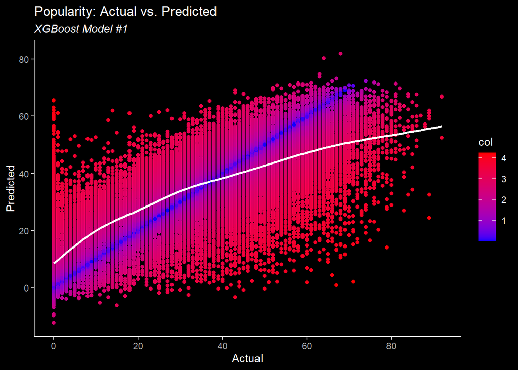

```r
plot_data <- cbind.data.frame(spot_test_dat$popularity,spot_bst_preds_1)
names(plot_data) <- c("Actual","Predicted")
plot_data$col <- log(abs(plot_data$Actual - plot_data$Predicted) + 1)
act_pred_1 <- ggplot(plot_data, aes(x=Actual,y=Predicted,color = col)) +
  dark_theme_bw() +
  geom_point() +
  geom_smooth(color="white", se = FALSE) +
  scale_color_gradient(low = "blue", high = "red")+
   labs(title = "Popularity: Actual vs. Predicted",
       subtitle = "XGBoost Model #1") +
  theme(axis.line = element_line(colour = "white"),
        panel.grid.major = element_blank(),
        panel.grid.minor = element_blank(),
        panel.border = element_blank(),
        panel.background = element_blank(),
        plot.subtitle = element_text(face = "italic"))+
  scale_x_continuous(breaks=seq(from = 0, to = 100, by = 20)) +
  scale_y_continuous(breaks=seq(from = 0, to = 100, by = 20))
act_pred_1
```

As seen above, we have a positive slope for Predicted vs. Actual line. The blue line that runs through the plot signifies pretty much every song that was accurately predicted, with every point in red an incorrect prediction for the song’s popularity. The further away a point is from the blue, the more inaccurate the prediction of popularity was.

### RMSE Breakdown

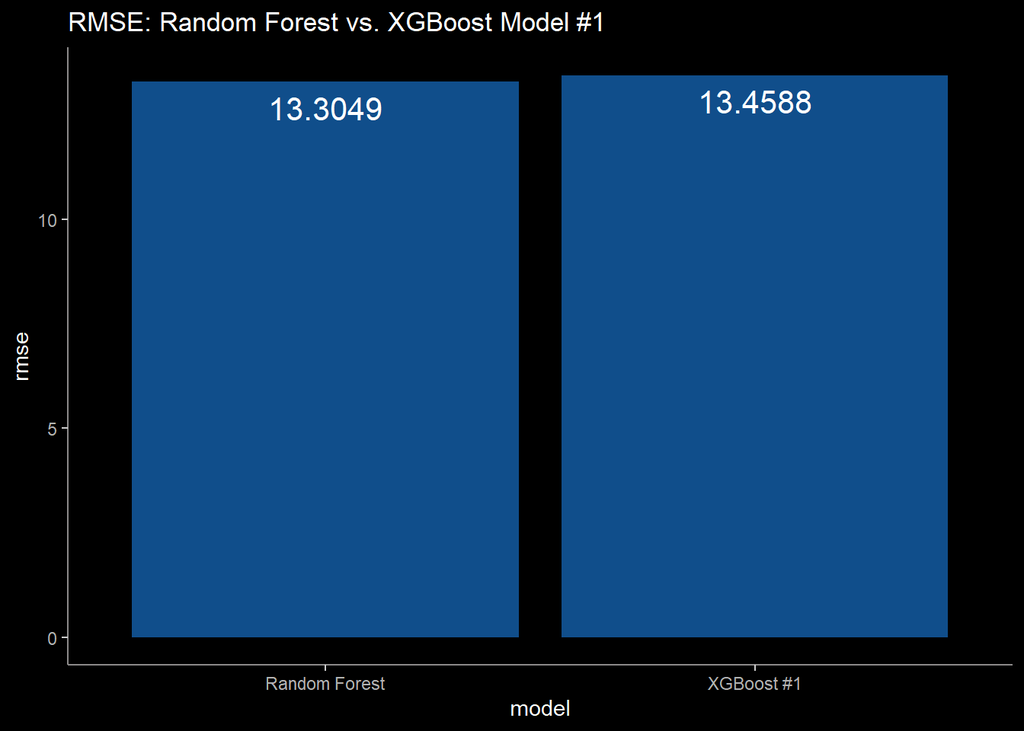

```r
rmse_df <- data.frame(model=c("Random Forest", "XGBoost #1"),
                rmse=c(spot_bag_rmse, spot_bst_1_rmse))

rmse_bar <-ggplot(data=rmse_df, aes(x=model, y=rmse)) +
  geom_bar(stat="identity", fill="dodgerblue4")+
    geom_text(aes(label=round(rmse, digits = 4)), vjust=1.6, color="white", size=5.5)+
  dark_theme_bw() +
  labs(title = "RMSE: Random Forest vs. XGBoost Model #1") +
  theme(axis.line = element_line(colour = "snow4"),
        panel.grid.major = element_blank(),
        panel.grid.minor = element_blank(),
        panel.border = element_blank(),
        panel.background = element_blank())
rmse_bar
```

As we can see, the RMSE for both the Random Forest Model and the initial XGBoost Model are essentially the same at 13.25-13.5 for the Test Set. However, one thing to note is that our initial XGBoost Model RMSE is slightly higher than the Random Forest Model. Let’s tune our XGBoost Model and see if we can get increase its accuracy in order to decrease get the RMSE down.

### Tuning XGBoost Model

Lets run our algorithm with a high number of trees and a learning rate of 0.1 to determine an appropriate number of trees to use.

**Parameter Tuning**

```r
# Use xgb.cv to run cross-validation inside xgboost
set.seed(2374)
bst <- xgb.cv(data = spot_dtrain, # Set training data

              nfold = 5, # Use 5 fold cross-validation

               eta = 0.1, # Set learning rate

               nrounds = 1000, # Set number of rounds
               early_stopping_rounds = 50, # Set number of rounds to stop at if there is no improvement

               verbose = 1, # 1 - Prints out fit
               nthread = 1, # Set number of parallel threads
               print_every_n = 20) # Prints out result every 20th iteration
```

```
## Multiple eval metrics are present. Will use test_rmse for early stopping.
## Will train until test_rmse hasn't improved in 50 rounds.
##
## Stopping. Best iteration:
```

From this, we see 432 was the optimal number of iterations for our model.

Next, we will set the number of iterations to 500 and include an early stop parameter of 50 for our next round of tuning. Next up we will tune max.depth and min_child_weight as these are likely to have the largest effect on model outcome.

**Maximum Depth & Minimum Child Weight Tuning**

```r
# Be Careful - This can take a very long time to run
max_depth_vals <- c(3, 5, 7, 10, 15) # Create vector of max depth values
min_child_weight <- c(1,3,5,7, 10, 15) # Create vector of min child values

# Expand grid of parameter values
cv_params <- expand.grid(max_depth_vals, min_child_weight)
names(cv_params) <- c("max_depth", "min_child_weight")
# Create results vector
rmse_vec <- rmsle_vec <- mae_vec <- rep(NA, nrow(cv_params))

# Loop through results
for(i in 1:nrow(cv_params)){
  set.seed(2374)
  bst_tune <- xgb.cv(data = spot_dtrain, # Set training data

    nfold = 5, # Use 5 fold cross-validation

    eta = 0.1, # Set learning rate
    max.depth = cv_params$max_depth[i], # Set max depth
    min_child_weight = cv_params$min_child_weight[i], # Set minimum number of samples in node to split


    nrounds = 500, # Set number of rounds
    early_stopping_rounds = 50, # Set number of rounds to stop at if there is no improvement

    verbose = 1, # 1 - Prints out fit
    nthread = 1, # Set number of parallel threads
    print_every_n = 20,
    eval_metric = "rmsle",
    eval_metric = "mae",
    eval_metric = "rmse") # Prints out result every 20th iteration


  rmse_vec[i] <- bst_tune$evaluation_log$test_rmse_mean[bst_tune$best_ntreelimit]
  rmsle_vec[i] <- bst_tune$evaluation_log$test_rmsle_mean[bst_tune$best_ntreelimit]
  mae_vec[i] <- bst_tune$evaluation_log$test_mae_mean[bst_tune$best_ntreelimit]
}
```

[output not shown]

[output cut: 70 more lines]

[output not shown]

Now, let us visualize those results to see which combination of max_depth and min_child_weight will minimize our RMSE, RMSLE, MAE.

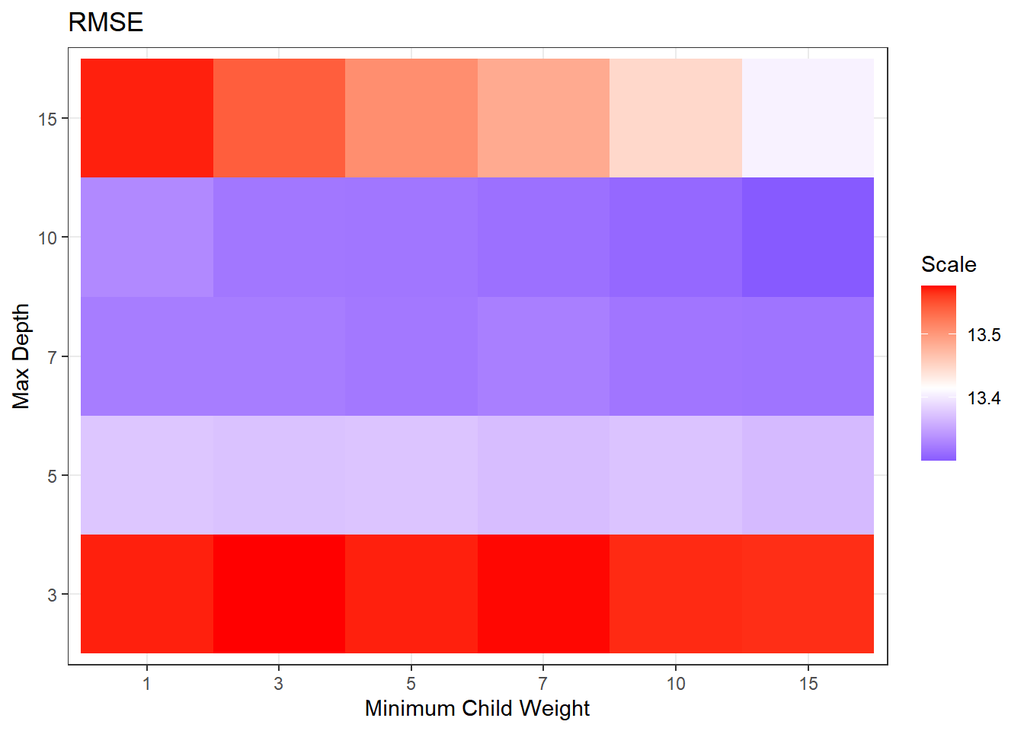

```r
# Join results in dataset
res_db <- cbind.data.frame(cv_params, rmse_vec, rmsle_vec, mae_vec)
names(res_db)[3:5] <- c("rmse", "rmsle", "mae")
res_db$max_depth <- as.factor(res_db$max_depth) # Convert tree number to factor for plotting
res_db$min_child_weight <- as.factor(res_db$min_child_weight) # Convert node size to factor for plotting
# Print RMSE heatmap
g_2 <- ggplot(res_db, aes(y = max_depth, x = min_child_weight, fill = rmse)) + # set aesthetics
  geom_tile() + # Use geom_tile for heatmap
  theme_bw() + # Set theme
  scale_fill_gradient2(low = "blue", # Choose low color
    mid = "white", # Choose mid color
    high = "red", # Choose high color
    midpoint =mean(res_db$rmse), # Choose mid point
    space = "Lab",
    na.value ="grey", # Choose NA value
    guide = "colourbar", # Set color bar
    aesthetics = "fill") + # Select aesthetics to apply
  labs(title = "RMSE", x = "Minimum Child Weight", y = "Max Depth", fill = "Scale") # Set labels
g_2 # Generate plot
```

[figure not shown]

```r
# print RMSLE heatmap
g_3 <- ggplot(res_db, aes(y = max_depth, x = min_child_weight, fill = rmsle)) + # set aesthetics
  geom_tile() + # Use geom_tile for heatmap
  theme_bw() + # Set theme
  scale_fill_gradient2(low = "blue", # Choose low color
    mid = "white", # Choose mid color
    high = "red", # Choose high color
    midpoint =mean(res_db$rmsle), # Choose mid point
    space = "Lab",
    na.value ="grey", # Choose NA value
    guide = "colourbar", # Set color bar
    aesthetics = "fill") + # Select aesthetics to apply
  labs(title = "RMSLE", x = "Minimum Child Weight", y = "Max Depth", fill = "Scale") # Set labels
g_3 # Generate plot
```

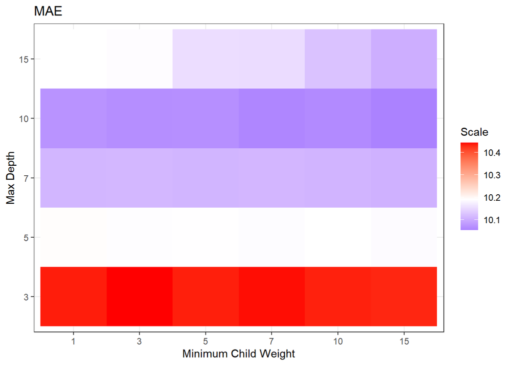

```r
# print MAE heatmap
g_4 <- ggplot(res_db, aes(y = max_depth, x = min_child_weight, fill = mae)) + # set aesthetics
  geom_tile() + # Use geom_tile for heatmap
  theme_bw() + # Set theme
  scale_fill_gradient2(low = "blue", # Choose low color
    mid = "white", # Choose mid color
    high = "red", # Choose high color
    midpoint =mean(res_db$mae), # Choose mid point
    space = "Lab",
    na.value ="grey", # Choose NA value
    guide = "colourbar", # Set color bar
    aesthetics = "fill") + # Select aesthetics to apply
  labs(title = "MAE", x = "Minimum Child Weight", y = "Max Depth", fill = "Scale") # Set labels
g_4 # Generate plot
```

From the visualization, we can see that a max_depth and min_child_weight combination of 10 and 15 yields us the lowest RMSE at this point of tuning. Thus, it is the optimal combination to use in our model.

One thing to note is that negative predictions for RMSLE is causing null values, thereby breaking the results from being visualized. Therefore, will will not be evaluating those results in finding optimal values for our model

Now, taking those optimal values, let us apply them to our model and tune the gamma value.

**Gamma Tuning**

```r
gamma_vals <- c(0, 0.05, 0.1, 0.15, 0.2) # Create vector of gamma values

# Be Careful - This can take a very long time to run
set.seed(2374)
# Create results vector
rmse_vec <- rmsle_vec <- mae_vec <- rep(NA, length(gamma_vals))
for(i in 1:length(gamma_vals)){
  bst_tune <- xgb.cv(data = spot_dtrain, # Set training data

              nfold = 5, # Use 5 fold cross-validation

              eta = 0.1, # Set learning rate
              max.depth = 10, # Set max depth
              min_child_weight = 15, # Set minimum number of samples in node to split
              gamma = gamma_vals[i], # Set minimum loss reduction for split



              nrounds = 500, # Set number of rounds
              early_stopping_rounds = 50, # Set number of rounds to stop at if there is no improvement

              verbose = 1, # 1 - Prints out fit
              nthread = 1, # Set number of parallel threads
              print_every_n = 20, # Prints out result every 20th iteration

              eval_metric = "rmsle",
              eval_metric = "mae",
              eval_metric = "rmse") # Prints out result every 20th iteration


  rmse_vec[i] <- bst_tune$evaluation_log$test_rmse_mean[bst_tune$best_ntreelimit]
  rmsle_vec[i] <- bst_tune$evaluation_log$test_rmsle_mean[bst_tune$best_ntreelimit]
  mae_vec[i] <- bst_tune$evaluation_log$test_mae_mean[bst_tune$best_ntreelimit]
}
```

```
## Multiple eval metrics are present. Will use test_rmse for early stopping.
## Will train until test_rmse hasn't improved in 50 rounds.
##
## Stopping. Best iteration:
##
## Multiple eval metrics are present. Will use test_rmse for early stopping.
## Will train until test_rmse hasn't improved in 50 rounds.
##
## Stopping. Best iteration:
##
## Multiple eval metrics are present. Will use test_rmse for early stopping.
## Will train until test_rmse hasn't improved in 50 rounds.
##
## Stopping. Best iteration:
##
## Multiple eval metrics are present. Will use test_rmse for early stopping.
## Will train until test_rmse hasn't improved in 50 rounds.
##
## Stopping. Best iteration:
##
## Multiple eval metrics are present. Will use test_rmse for early stopping.
## Will train until test_rmse hasn't improved in 50 rounds.
##
## Stopping. Best iteration:
```

Now, let’s bind those results into a table to see gamma is the most optimal for our model.

```r
cbind.data.frame(gamma_vals,rmse_vec,rmsle_vec,mae_vec)
```

```
##   gamma_vals rmse_vec rmsle_vec  mae_vec
## 1       0.00 13.30161       NaN 10.05522
## 2       0.05 13.30726       NaN 10.05979
## 3       0.10 13.31345       NaN 10.06136
## 4       0.15 13.30326       NaN 10.05610
## 5       0.20 13.31798       NaN 10.07274
```

From these values, we can see that a gamma value of 0.00 gives us the lowest RMSE.

Next, let’s apply our min_child_weight, max_depth, and gamma values to tune subsample and column samples.

**Subsample & Column Sample Tuning**

```r
# Be Careful - This can take a very long time to run
subsample <- c(0.6, 0.7, 0.8, 0.9, 1) # Create vector of subsample values
colsample_by_tree <- c(0.6, 0.7, 0.8, 0.9, 1) # Create vector of col sample values

# Expand grid of tuning parameters
cv_params <- expand.grid(subsample, colsample_by_tree)
names(cv_params) <- c("subsample", "colsample_by_tree")
# Create results vector
rmse_vec <- rmsle_vec <- mae_vec <- rep(NA, nrow(cv_params))
# Loop through parameter values
for(i in 1:nrow(cv_params)){
  set.seed(2374)
  bst_tune <- xgb.cv(data = spot_dtrain, # Set training data

              nfold = 5, # Use 5 fold cross-validation

              eta = 0.1, # Set learning rate
              max.depth = 10, # Set max depth
              min_child_weight = 15, # Set minimum number of samples in node to split
              gamma = 0.0, # Set minimum loss reduction for split
              subsample = cv_params$subsample[i], # Set proportion of training data to use in tree
              colsample_bytree = cv_params$colsample_by_tree[i], # Set number of variables to use in each tree

              nrounds = 500, # Set number of rounds
              early_stopping_rounds = 50, # Set number of rounds to stop at if there is no improvement

              verbose = 1, # 1 - Prints out fit
              nthread = 1, # Set number of parallel threads
              print_every_n = 20, # Prints out result every 20th iteration

              eval_metric = "rmsle",
              eval_metric = "mae",
              eval_metric = "rmse") # Prints out result every 20th iteration


  rmse_vec[i] <- bst_tune$evaluation_log$test_rmse_mean[bst_tune$best_ntreelimit]
  rmsle_vec[i] <- bst_tune$evaluation_log$test_rmsle_mean[bst_tune$best_ntreelimit]
  mae_vec[i] <- bst_tune$evaluation_log$test_mae_mean[bst_tune$best_ntreelimit]
}
```

[output not shown]

[output cut: 69 more lines]

[output not shown]

Now, let’s us visualize the results.

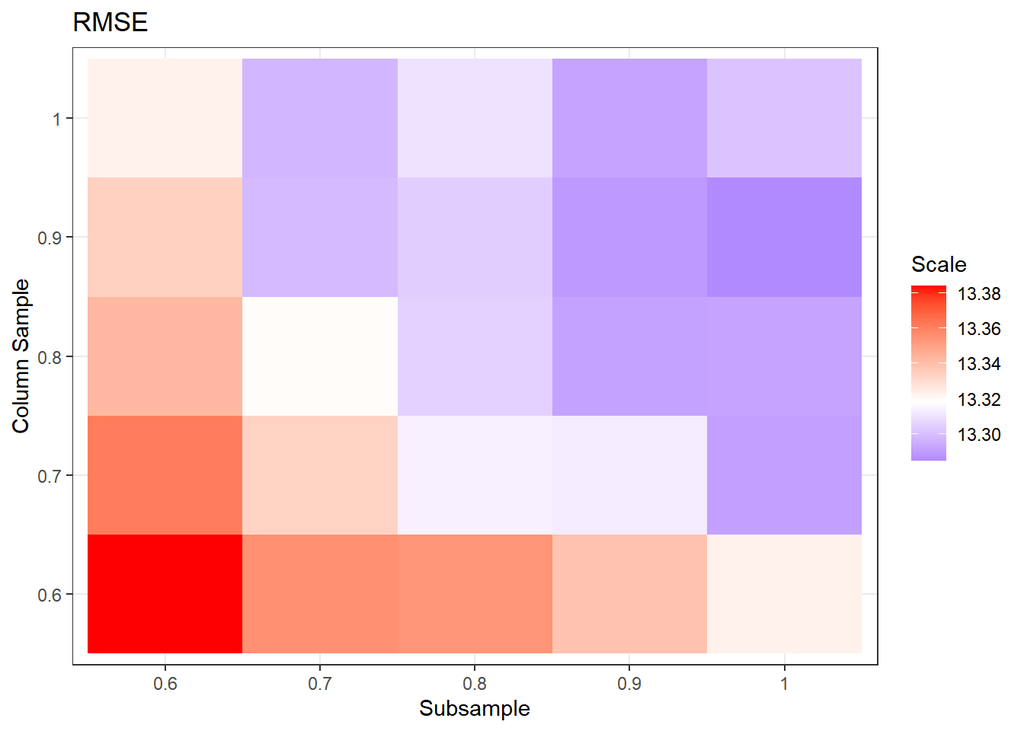

```r
# Join results in dataset
res_db <- cbind.data.frame(cv_params, rmse_vec, rmsle_vec, mae_vec)
names(res_db)[3:5] <- c("rmse", "rmsle", "mae")
res_db$colsample_by_tree <- as.factor(res_db$colsample_by_tree) # Convert tree number to factor for plotting
res_db$subsample <- as.factor(res_db$subsample) # Convert node size to factor for plotting
# Print RMSE heatmap
g_5 <- ggplot(res_db, aes(y = colsample_by_tree, x = subsample, fill = rmse)) + # set aesthetics
  geom_tile() + # Use geom_tile for heatmap
  theme_bw() + # Set theme
  scale_fill_gradient2(low = "blue", # Choose low color
    mid = "white", # Choose mid color
    high = "red", # Choose high color
    midpoint =mean(res_db$rmse), # Choose mid point
    space = "Lab",
    na.value ="grey", # Choose NA value
    guide = "colourbar", # Set color bar
    aesthetics = "fill") + # Select aesthetics to apply
  labs(title = "RMSE", x = "Subsample", y = "Column Sample", fill = "Scale") # Set labels
g_5 # Generate plot
```

[figure not shown]

```r
# print RMSLE heatmap
g_6 <- ggplot(res_db, aes(y = colsample_by_tree, x = subsample, fill = rmsle)) + # set aesthetics
  geom_tile() + # Use geom_tile for heatmap
  theme_bw() + # Set theme
  scale_fill_gradient2(low = "blue", # Choose low color
    mid = "white", # Choose mid color
    high = "red", # Choose high color
    midpoint =mean(res_db$rmsle), # Choose mid point
    space = "Lab",
    na.value ="grey", # Choose NA value
    guide = "colourbar", # Set color bar
    aesthetics = "fill") + # Select aesthetics to apply
  labs(title = "RMSLE", x = "Subsample", y = "Column Sample", fill = "Scale") # Set labels
g_6 # Generate plot
```

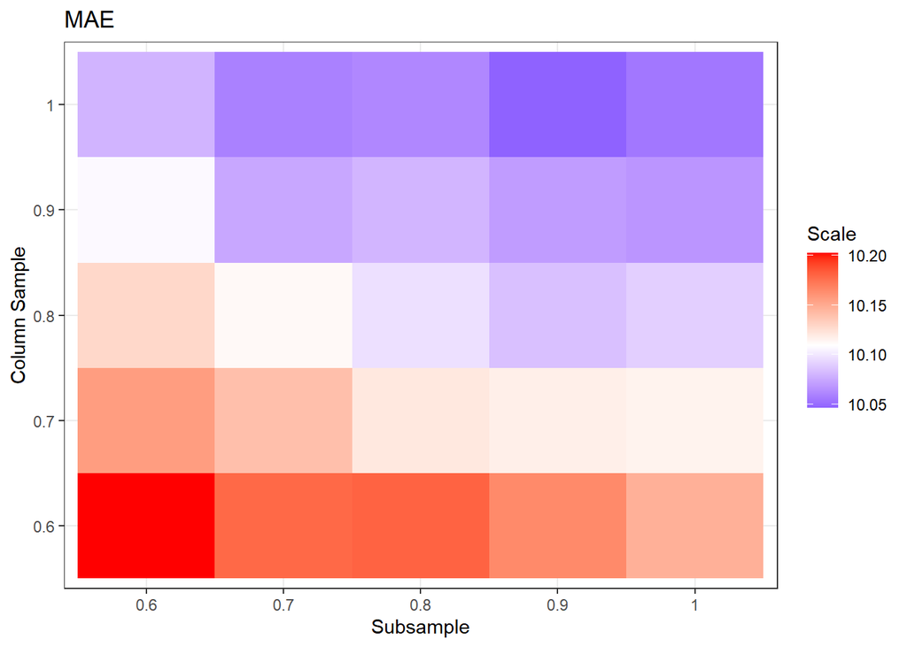

```r
# print MAE heatmap
g_7 <- ggplot(res_db, aes(y = colsample_by_tree, x = subsample, fill = mae)) + # set aesthetics
  geom_tile() + # Use geom_tile for heatmap
  theme_bw() + # Set theme
  scale_fill_gradient2(low = "blue", # Choose low color
    mid = "white", # Choose mid color
    high = "red", # Choose high color
    midpoint =mean(res_db$mae), # Choose mid point
    space = "Lab",
    na.value ="grey", # Choose NA value
    guide = "colourbar", # Set color bar
    aesthetics = "fill") + # Select aesthetics to apply
  labs(title = "MAE", x = "Subsample", y = "Column Sample", fill = "Scale") # Set labels
g_7 # Generate plot
```

Here, we see that a col_sample and subsample combination of 0.9-1 gives the lowest RMSE, with the previous components of tuning taken into account.

The last step then is to tune ETA.

**eta Tuning**

```r
# Use xgb.cv to run cross-validation inside xgboost
set.seed(2374)
bst_mod_1 <- xgb.cv(data = spot_dtrain, # Set training data

              nfold = 5, # Use 5 fold cross-validation

              eta = 0.3, # Set learning rate
              max.depth = 10, # Set max depth
              min_child_weight = 15, # Set minimum number of samples in node to split
              gamma = 0.0, # Set minimum loss reduction for split
              subsample = 1, # Set proportion of training data to use in tree
              colsample_bytree = 0.9, # Set number of variables to use in each tree

              nrounds = 1000, # Set number of rounds
              early_stopping_rounds = 20, # Set number of rounds to stop at if there is no improvement

              verbose = 1, # 1 - Prints out fit
              nthread = 1, # Set number of parallel threads
              print_every_n = 20, # Prints out result every 20th iteration

              eval_metric = "rmsle",
              eval_metric = "mae",
              eval_metric = "rmse") # Prints out result every 20th iteration
```

```
## Multiple eval metrics are present. Will use test_rmse for early stopping.
## Will train until test_rmse hasn't improved in 20 rounds.
##
## Stopping. Best iteration:
```

```r
set.seed(2374)
bst_mod_2 <- xgb.cv(data = spot_dtrain, # Set training data

              nfold = 5, # Use 5 fold cross-validation

              eta = 0.1, # Set learning rate
              max.depth =  10, # Set max depth
              min_child_weight = 15, # Set minimum number of samples in node to split
              gamma = 0.0, # Set minimum loss reduction for split
              subsample = 1, # Set proportion of training data to use in tree
              colsample_bytree = 0.9, # Set number of variables to use in each tree

              nrounds = 1000, # Set number of rounds
              early_stopping_rounds = 20, # Set number of rounds to stop at if there is no improvement

              verbose = 1, # 1 - Prints out fit
              nthread = 1, # Set number of parallel threads
              print_every_n = 20, # Prints out result every 20th iteration

              eval_metric = "rmsle",
              eval_metric = "mae",
              eval_metric = "rmse") # Prints out result every 20th iteration
```

```
## Multiple eval metrics are present. Will use test_rmse for early stopping.
## Will train until test_rmse hasn't improved in 20 rounds.
##
## Stopping. Best iteration:
```

```r
set.seed(2374)
bst_mod_3 <- xgb.cv(data = spot_dtrain, # Set training data

              nfold = 5, # Use 5 fold cross-validation

              eta = 0.05, # Set learning rate
              max.depth = 10, # Set max depth
              min_child_weight = 15, # Set minimum number of samples in node to split
              gamma = 0.0, # Set minimum loss reduction for split
              subsample = 1, # Set proportion of training data to use in tree
              colsample_bytree =  0.9, # Set number of variables to use in each tree

              nrounds = 1000, # Set number of rounds
              early_stopping_rounds = 20, # Set number of rounds to stop at if there is no improvement

              verbose = 1, # 1 - Prints out fit
              nthread = 1, # Set number of parallel threads
              print_every_n = 20, # Prints out result every 20th iteration

              eval_metric = "rmsle",
              eval_metric = "mae",
              eval_metric = "rmse") # Prints out result every 20th iteration
```

```
## Multiple eval metrics are present. Will use test_rmse for early stopping.
## Will train until test_rmse hasn't improved in 20 rounds.
##
## Stopping. Best iteration:
```

```r
set.seed(2374)
bst_mod_4 <- xgb.cv(data = spot_dtrain, # Set training data

              nfold = 5, # Use 5 fold cross-validation

              eta = 0.01, # Set learning rate
              max.depth = 10, # Set max depth
              min_child_weight = 15, # Set minimum number of samples in node to split
              gamma = 0.0, # Set minimum loss reduction for split
              subsample = 1, # Set proportion of training data to use in tree
              colsample_bytree = 0.9, # Set number of variables to use in each tree

              nrounds = 1000, # Set number of rounds
              early_stopping_rounds = 20, # Set number of rounds to stop at if there is no improvement

              verbose = 1, # 1 - Prints out fit
              nthread = 1, # Set number of parallel threads
              print_every_n = 20, # Prints out result every 20th iteration

              eval_metric = "rmsle",
              eval_metric = "mae",
              eval_metric = "rmse") # Prints out result every 20th iteration
```

```
## Multiple eval metrics are present. Will use test_rmse for early stopping.
## Will train until test_rmse hasn't improved in 20 rounds.
##
```

```r
set.seed(2374)
bst_mod_5 <- xgb.cv(data = spot_dtrain, # Set training data

              nfold = 5, # Use 5 fold cross-validation

              eta = 0.005, # Set learning rate
              max.depth = 10, # Set max depth
              min_child_weight = 15, # Set minimum number of samples in node to split
              gamma = 0.0, # Set minimum loss reduction for split
              subsample = 1 , # Set proportion of training data to use in tree
              colsample_bytree = 0.9, # Set number of variables to use in each tree

              nrounds = 1000, # Set number of rounds
              early_stopping_rounds = 20, # Set number of rounds to stop at if there is no improvement

              verbose = 1, # 1 - Prints out fit
              nthread = 1, # Set number of parallel threads
              print_every_n = 20, # Prints out result every 20th iteration

              eval_metric = "rmsle",
              eval_metric = "mae",
              eval_metric = "rmse") # Prints out result every 20th iteration
```

```
## Multiple eval metrics are present. Will use test_rmse for early stopping.
## Will train until test_rmse hasn't improved in 20 rounds.
##
```

We can then plot the error rate over different learning rates:

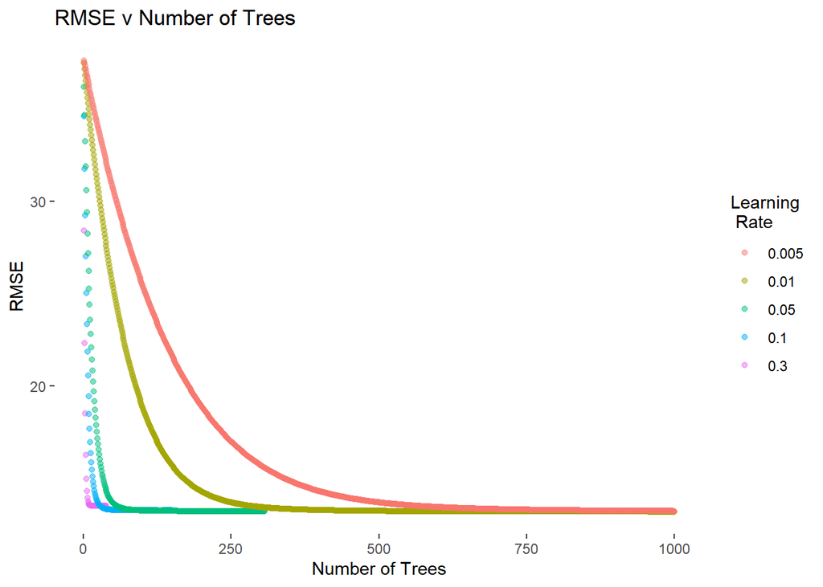

```r
# Extract results for model with eta = 0.3
pd1 <- cbind.data.frame(bst_mod_1$evaluation_log[,c("iter", "test_rmse_mean")], rep(0.3, nrow(bst_mod_1$evaluation_log)))
names(pd1)[3] <- "eta"
# Extract results for model with eta = 0.1
pd2 <- cbind.data.frame(bst_mod_2$evaluation_log[,c("iter", "test_rmse_mean")], rep(0.1, nrow(bst_mod_2$evaluation_log)))
names(pd2)[3] <- "eta"
# Extract results for model with eta = 0.05
pd3 <- cbind.data.frame(bst_mod_3$evaluation_log[,c("iter", "test_rmse_mean")], rep(0.05, nrow(bst_mod_3$evaluation_log)))
names(pd3)[3] <- "eta"
# Extract results for model with eta = 0.01
pd4 <- cbind.data.frame(bst_mod_4$evaluation_log[,c("iter", "test_rmse_mean")], rep(0.01, nrow(bst_mod_4$evaluation_log)))
names(pd4)[3] <- "eta"
# Extract results for model with eta = 0.005
pd5 <- cbind.data.frame(bst_mod_5$evaluation_log[,c("iter", "test_rmse_mean")], rep(0.005, nrow(bst_mod_5$evaluation_log)))
names(pd5)[3] <- "eta"
# Join datasets
plot_data <- rbind.data.frame(pd1, pd2, pd3, pd4, pd5)
# Converty ETA to factor
plot_data$eta <- as.factor(plot_data$eta)
# Plot points
g_8 <- ggplot(plot_data, aes(x = iter, y = test_rmse_mean, color = eta))+
  geom_point(alpha = 0.5) +
  theme_bw() + # Set theme
  theme(panel.grid.major = element_blank(), # Remove grid
        panel.grid.minor = element_blank(), # Remove grid
        panel.border = element_blank(), # Remove grid
        panel.background = element_blank()) + # Remove grid
  labs(x = "Number of Trees", title = "RMSE v Number of Trees",
       y = "RMSE", color = "Learning \n Rate")  # Set labels
g_8
```

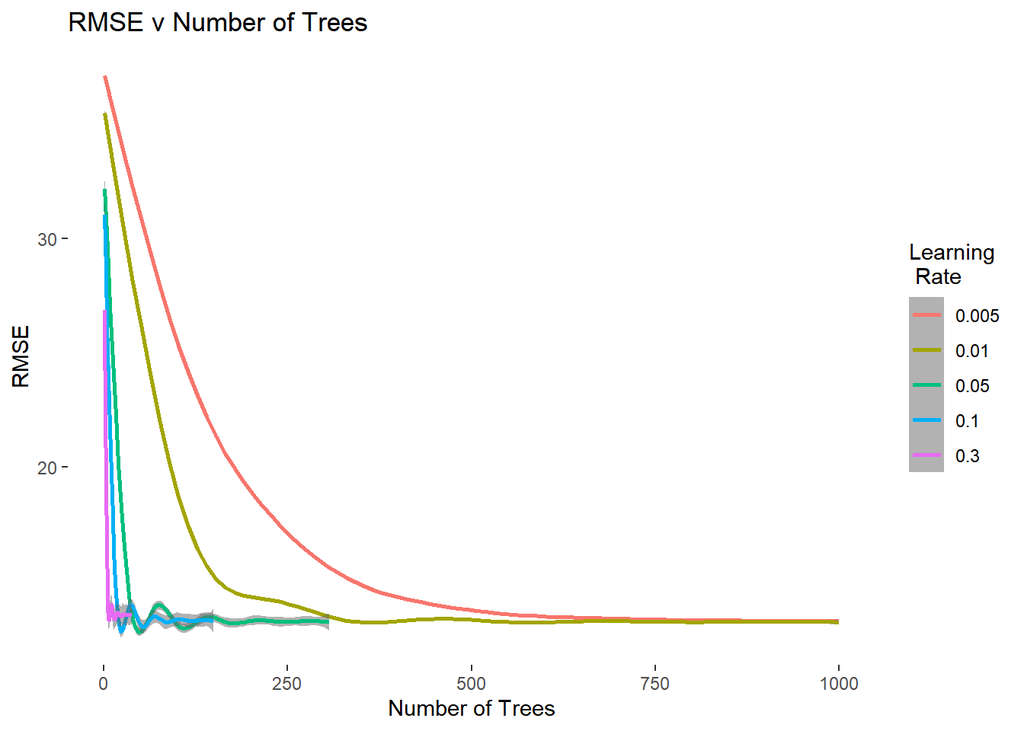

```r
# Plot lines
g_9 <- ggplot(plot_data, aes(x = iter, y = test_rmse_mean, color = eta))+
  geom_smooth(alpha = 0.5) +
  theme_bw() + # Set theme
  theme(panel.grid.major = element_blank(), # Remove grid
        panel.grid.minor = element_blank(), # Remove grid
        panel.border = element_blank(), # Remove grid
        panel.background = element_blank()) + # Remove grid
  labs(x = "Number of Trees", title = "RMSE v Number of Trees",
       y = "RMSE", color = "Learning \n Rate")  # Set labels
g_9
```

From this we see that 0.05 is the ETA with the best learning rate, as it minimizes RMSE in our model.

### Plot the Best XGBoost Model

```r
set.seed(2374)
bst_final <- xgboost(data = spot_dtrain, # Set training data



              eta = 0.05, # Set learning rate
              max.depth =  10, # Set max depth
              min_child_weight = 15, # Set minimum number of samples in node to split
              gamma = 0.00, # Set minimum loss reduction for split
              subsample =  1, # Set proportion of training data to use in tree
              colsample_bytree = 0.9, # Set number of variables to use in each tree

              nrounds = 150, # Set number of rounds
              early_stopping_rounds = 20, # Set number of rounds to stop at if there is no improvement

              verbose = 1, # 1 - Prints out fit
              nthread = 1, # Set number of parallel threads
              print_every_n = 20, # Prints out result every 20th iteration

              eval_metric = "rmsle",
              eval_metric = "mae",
              eval_metric = "rmse") # Prints out result every 20th iteration
```

```
## Multiple eval metrics are present. Will use train_rmse for early stopping.
## Will train until train_rmse hasn't improved in 20 rounds.
##
```

```r
#save(bst_final, file = "bst_final_spotify.rda")
#load('bst_final_spotify.rda')
```

### Create Predictions against the Test Set

```r
spot_bst_preds_2 <- predict(bst_final, spot_dtest) # Create predictions for xgboost model
spot_bst_2_rmse <- rmse(actual = spot_test_dat$popularity, predicted = spot_bst_preds_2)

spot_bst_2_rmse
```

```
## [1] 13.26094
```

### Plot the Results of Predictions

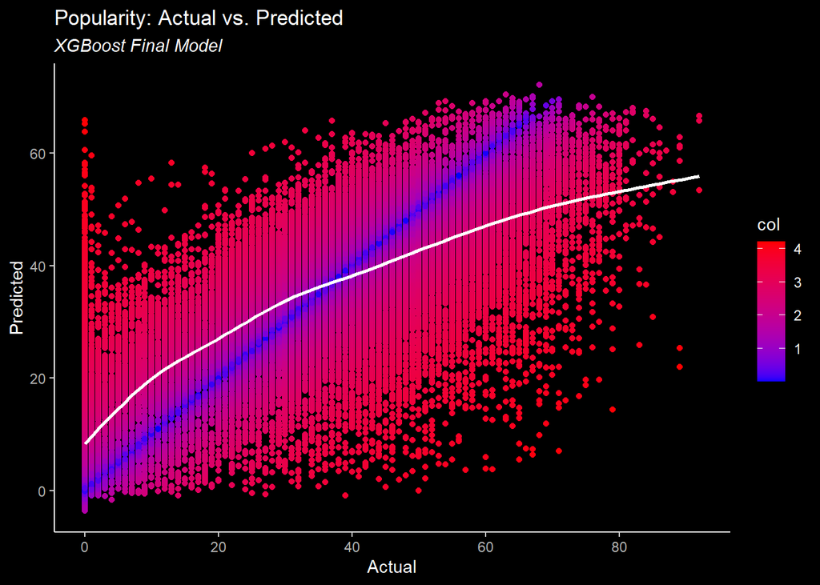

```r
plot_data2 <- cbind.data.frame(spot_test_dat$popularity,spot_bst_preds_2)
names(plot_data2) <- c("Actual","Predicted")
plot_data2$col <- log(abs(plot_data2$Actual - plot_data2$Predicted) + 1)
act_pred_2 <- ggplot(plot_data2, aes(x=Actual,y=Predicted,color = col)) +
  dark_theme_bw() +
  geom_point() +
  geom_smooth(color="white", se=FALSE) +
  scale_color_gradient(low = "blue", high = "red") +
   labs(title = "Popularity: Actual vs. Predicted",
       subtitle = "XGBoost Final Model") +
  theme(axis.line = element_line(colour = "white"),
        panel.grid.major = element_blank(),
        panel.grid.minor = element_blank(),
        panel.border = element_blank(),
        panel.background = element_blank(),
        plot.subtitle = element_text(face = "italic"))+
  scale_x_continuous(breaks=seq(from = 0, to = 100, by = 20)) +
  scale_y_continuous(breaks=seq(from = 0, to = 100, by = 20))
act_pred_2
```

While this looks similar to our original model, there has been some improvement, as evidenced by the increased slope of our graph. Furthermore, more of the songs in our test set are being accurately predicted, as they are falling within the blue part of our graph, increasing the size of that part of the visualization.

### Plotting of RMSE against Three Models

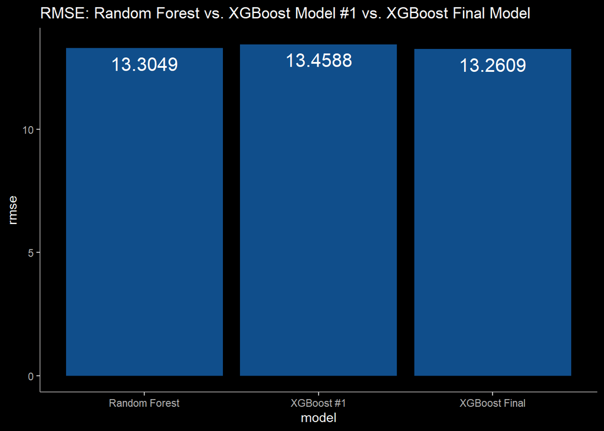

```r
rmse_df_2 <- data.frame(model=c("Random Forest", "XGBoost #1", "XGBoost Final"),
                rmse=c(spot_bag_rmse, spot_bst_1_rmse, spot_bst_2_rmse))

rmse_bar_2 <-ggplot(data=rmse_df_2, aes(x=model, y=rmse)) +
  geom_bar(stat="identity", fill="dodgerblue4")+
    geom_text(aes(label=round(rmse, digits = 4)), vjust=1.6, color="white", size=5.5)+
  dark_theme_bw() +
  labs(title = "RMSE: Random Forest vs. XGBoost Model #1 vs. XGBoost Final Model") +
  theme(axis.line = element_line(colour = "snow4"),
        panel.grid.major = element_blank(),
        panel.grid.minor = element_blank(),
        panel.border = element_blank(),
        panel.background = element_blank())
rmse_bar_2
```

As we can see, tuning our model has decreased RMSE by roughly ~0.20 against the test test compared to the original XGBoost model. Furthermore, tuning our XGBoost model also pushed our RMSE below the Random Forest Model RMSE.

### Variable Importance

Now let’s plot the results to see which variables have importance/significance in determining a song’s popularity rating.

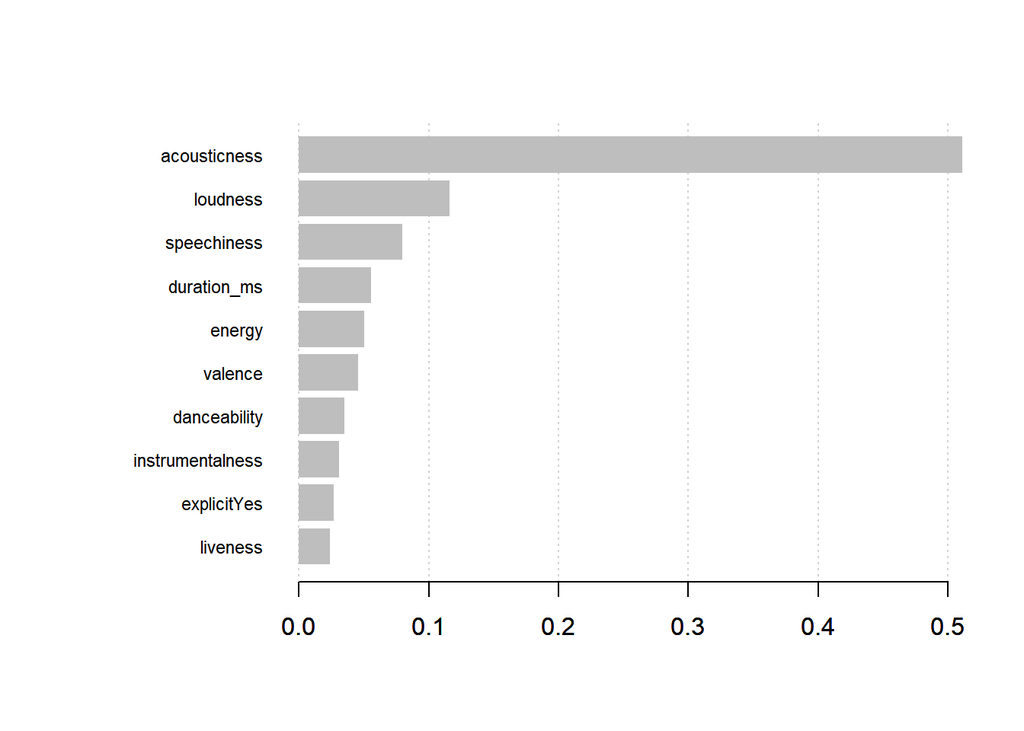

```r
# Extract importance
imp_mat <- xgb.importance(model = bst_final)
# Plot importance (top 10 variables)
xgb.plot.importance(imp_mat, top_n = 10)
```

From the above, we see that acousticness, loudness, and speechiness are our top three most important variables when determining the popularity of a song, with acousticness being very significant in determining a song’s popularity.

### SHAP Variable Importance

The above is great information, but we want to know what amounts of those song characteristics shape a song’s popularity. Thus, let’s plot variable importance using SHAP to get a sense of that.

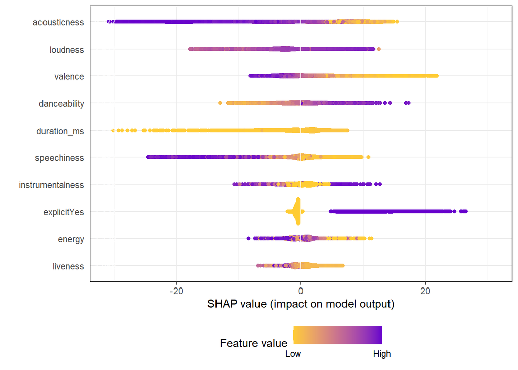

```r
load("shap_long_new_2.rda")

#source("a_insights_shap_functions.r")
plot.shap.summary(data_long = shap_long)
```

As we can see, a great deal of information can be derived from above. The biggest takeaway is that acousticness, the most significant variable in determining a song’s popularity, actually needs to be less present in a song for a song to have a higher popularity rating. This makes sense because in this dataset, songs of more recent years tend to have higher popularity songs, and songs of recent years have little to no acousticness in them compared to songs of earlier years. Many others conclusions can be made by studying this plot and applying it to the trends of the music industry over time.

# Conclusions

Overall, the RMSE might seem high, even after tuning, but we believe it to be a fair number. This is because we did not incorporate artist name into the model, which we believe to have a huge factor in a song’s popularity, based off the way popularity is calculated in the dataset. Furthermore, we did not incorporate the year variable into our model. We originally did, but the it was skewing the results of the variable importance, as more recent songs have a higher popularity ratings. Therefore, this recency bias in the dataset was not allowing us to see what components of songs make up popularity. So, it was removed from the model and reran.

With those variables excluded, we expected the RMSE to go up, as less variables were being included to run the model. However, that trade-off allowed us to bypass the artist name and release year of songs in order to find the physical components of music that make songs popular in the United States today. With this information, musicians, producers, record companies, etc. can study our findings and apply it to the music they are currently making in order to try and maximize the popularity of their song on Spotify.